# Proč mají větší ostrovy více druhů rostlin?

Tvar rozdělení, transformace a nelinearita — podkladové čtenářské materiály k přednášce

Publikováno

12. října 2026

Upraveno

21. října 2026

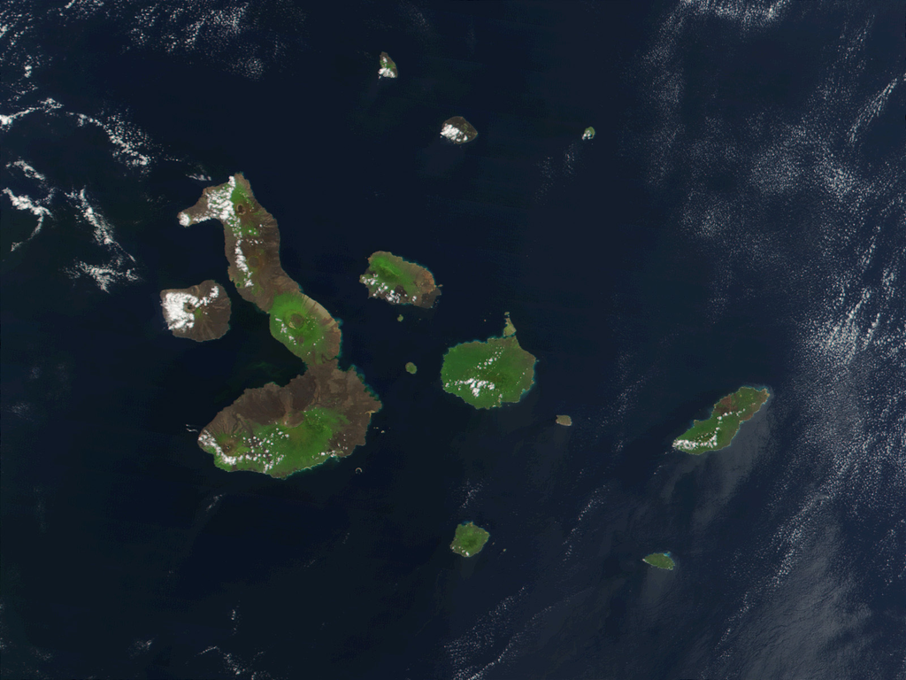

Souostroví Galapágy na družicovém snímku z 12. března 2002. Největší ostrov ve tvaru písmene L je Isabela, vlevo od něj leží Fernandina. Snímek: Jacques Descloitres, MODIS Rapid Response Project, NASA/GSFC (volné dílo).

Galapágy leží v Tichém oceánu asi tisíc kilometrů od pobřeží Ekvádoru. Na snímku je vidět, jak odlišné ostrovy souostroví tvoří: několik obrovských sopečných ostrovů a mnoho malých ostrůvků a skalek. Botanici na nich spočítali druhy cévnatých rostlin a zjistili, že větší ostrovy jich hostí více. Takový vztah ekologové znají z ostrovů, horských vrcholů i ostrůvků lesa v zemědělské krajině.

**QuestionHlavní otázka**

Jak rychle roste počet druhů rostlin s plochou ostrova? Má ostrov, který je dvakrát větší, také dvakrát více druhů?

Než si odpovíte, zkuste odhadnout: kdyby ostrov měl desetkrát větší plochu, kolikrát více druhů byste na něm čekali? Na konci lekce svůj odhad porovnáte s tím, co ukážou data.

# 1 Co prozradil oblouk v residuích stromů?

Abychom na otázku o ostrovech mohli odpovědět, budeme potřebovat popsat zakřivený vztahSituace, kdy vztah mezi prediktorem a odezvou není dobře popsatelný přímkou - má zakřivení nebo jinou nelineární formu.. S takovým vztahem jsme se setkali už v předchozí lekci, kde jsme porovnávali kandidátní modelyJeden z malé sady modelů, které před analýzou formulujeme podle biologických hypotéz a pak porovnáme na stejných datech. pro výšku jehličnanů. Nejlépe obhajitelný byl posun mezi druhy, tedy aditivní modelModel s více prediktory bez interakce: příspěvky prediktorů se sčítají, takže vztah odezvy k jednomu prediktoru je stejný při všech hodnotách ostatních. s průměrem kmene a druhem stromu. U jeho residuíRozdíl mezi pozorovanou hodnotou odezvy a hodnotou odhadnutou modelem: eᵢ = yᵢ − ŷᵢ. však zůstal jeden vzor, ke kterému se nyní vrátíme.

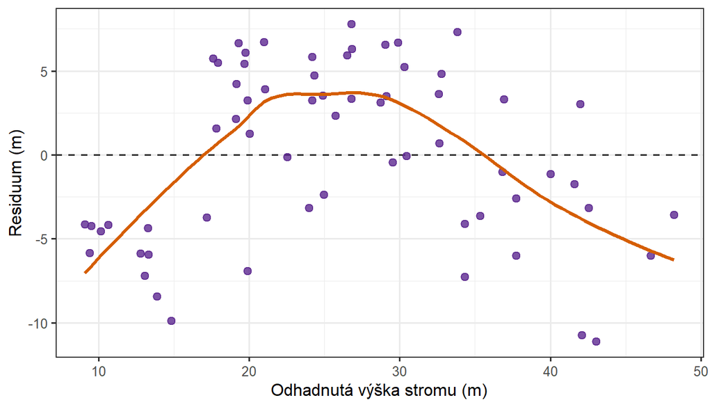

Residua aditivního modelu pro výšku stromů z předchozí lekce podle odhadnuté výšky. Oranžová křivka pouze vyhlazuje průběh bodů, aby byl vzor lépe vidět.

**QuestionCo residua říkají o přímce?**

Kde leží residua převážně nad nulou a kde pod nulou? Co by to znamenalo pro tvar vztahu mezi průměrem kmene a výškou stromu?

U nejmenších a největších stromů leží residua převážně pod nulou, uprostřed nad nulou. Model tedy u krajních stromů výšku systematicky přeceňuje a u středně velkých podceňuje. **Takový oblouk v residuích naznačuje, že skutečný vztah je zakřivený, zatímco model předpokládá přímku.** Žádná z porovnávaných přímek tento vzor neodstranila. Zda a jak oblouk zmizí, zjistíme ve chvíli, kdy budeme umět měnit tvar vztahu; k těmto stromům se vrátíme na konci lekce.

Předchozí lekce proto skončila otevřenou otázkou: co dělat, když žádný kandidát složený z přímek nestačí? Tato lekce na ni odpoví. Uvidíme, že lineární modelStatistický model, v němž je průměrná odezva součtem interceptu a prediktorů násobených koeficienty; lineární je v koeficientech, takže nemusí jít jen o přímku. umí popsat i zakřivený vztah, pokud vhodně upravíme proměnné. Předtím se ale musíme naučit popisovat **tvar** — tvar rozděleníPopis toho, jaké hodnoty proměnná nabývá a jak často se vyskytují; může jít o pozorované rozdělení dat nebo o teoretické pravděpodobnostní rozdělení. hodnot i tvar vztahu.

# 2 Co se v této lekci naučíte

Po prostudování lekce budete umět:

- popsat tvar rozděleníPopis toho, jaké hodnoty proměnná nabývá a jak často se vyskytují; může jít o pozorované rozdělení dat nebo o teoretické pravděpodobnostní rozdělení. proměnné nebo residuíRozdíl mezi pozorovanou hodnotou odezvy a hodnotou odhadnutou modelem: eᵢ = yᵢ − ŷᵢ. pomocí histogramuGraf zobrazující rozdělení hodnot numerické proměnné: hodnoty jsou rozděleny do sousedních intervalů (košů), výška sloupce udává četnost v daném koši. a Q–Q grafuGraf, který porovnává seřazené hodnoty (typicky residua) s kvantily očekávanými u zvoleného rozdělení, nejčastěji normálního. a posoudit, zda je tento tvar pro lineární modelStatistický model, v němž je průměrná odezva součtem interceptu a prediktorů násobených koeficienty; lineární je v koeficientech, takže nemusí jít jen o přímku. podstatný;
- rozlišit transformaceMatematická operace použitá na hodnoty proměnné (např. logaritmus); mění tvar rozdělení i to, jaký vztah model popisuje, například násobný místo součtového., které mění jen polohu a měřítko hodnot (změna jednotek, centrováníOdečtení průměru (nebo jiné zvolené hodnoty) od všech hodnot proměnné; posune polohu, ale nezmění tvar rozdělení ani rozptyl., z-skóreHodnota převedená na počet směrodatných odchylek od průměru: z = (x − průměr) / SD; mění polohu a měřítko, ne tvar rozdělení.), od transformací, které mění tvar (logaritmus, odmocnina);
- rozpoznat zakřivený vztahSituace, kdy vztah mezi prediktorem a odezvou není dobře popsatelný přímkou - má zakřivení nebo jinou nelineární formu. v datech a navrhnout jednoduché řešení;
- porovnat několik biologicky smysluplných tvarů vztahu jako kandidátní modelyJeden z malé sady modelů, které před analýzou formulujeme podle biologických hypotéz a pak porovnáme na stejných datech.;
- vysvětlit, jak transformace mění interpretaci koeficientů modelu.

# 3 Tvar rozdělení

## 3.1 Jeden řádek tabulky představuje jeden ostrov

Budeme pracovat s klasickými daty o rostlinách Galapág, která publikovali M. P. Johnson a P. H. Raven (1973). Každý řádek tabulky představuje jeden ostrov. Pro každý ostrov známe:

Proměnné ve výukové tabulce ostrovů Galapág.

| Proměnná | Význam | Jednotka |
| --- | --- | --- |
| `ostrov` | název ostrova | — |
| `pocet_druhu` | počet druhů cévnatých rostlin | počet |
| `pocet_endemitu` | počet druhů, které nerostou nikde jinde na světě | počet |
| `plocha_km2` | plocha ostrova | km² |
| `nejvyssi_bod_m` | nadmořská výška nejvyššího bodu ostrova | m n. m. |
| `vzdalenost_nejblizsi_km` | vzdálenost k nejbližšímu ostrovu | km |
| `vzdalenost_santa_cruz_km` | vzdálenost k ostrovu Santa Cruz | km |
| `plocha_sousedniho_km2` | plocha nejbližšího sousedního ostrova | km² |

Hlavní odezvouProměnná, jejíž variabilitu se snažíme vysvětlit nebo předpovědět; v notaci modelu y ~ x je odezva y. bude počet druhů rostlin a hlavním prediktoremProměnná, pomocí níž vysvětlujeme variabilitu odezvy; v notaci y ~ x je prediktor x. plocha ostrova. Ostatní proměnné použijeme pro srovnání tvarů rozděleníPopis toho, jaké hodnoty proměnná nabývá a jak často se vyskytují; může jít o pozorované rozdělení dat nebo o teoretické pravděpodobnostní rozdělení. a pro práci s různými jednotkami.

```r
# Načteme připravenou výukovou tabulku
data_ostrovy <-
  read.csv(
    file = here::here("data", "druhy_galapagy.csv"),
    stringsAsFactors = FALSE
  )
```

**TipDoplňující: původ dat a příprava tabulky**

Tabulka pochází z datasetu `galamiss` v balíčku [`faraway`](https://cran.r-project.org/package=faraway) verze 1.0.9 (J. Faraway), který je šířen pod licencí GPL. Hodnoty převzal z článku M. P. Johnson a P. H. Raven (1973): Species number and endemism: The Galapagos Archipelago revisited. *Science* 179: 893–895. Používáme verzi `galamiss`, která zachovává původní chybějící hodnoty. Sesterský dataset `gala` je pro pohodlí doplňuje, a proto jej nepoužíváme.

Následující kód stáhne zdrojový balíček z archivu CRAN, ověří jeho otisk SHA-256, načte z něj tabulku bez instalace balíčku a uloží výukovou verzi s českými názvy proměnných. Řádky ani hodnoty nemění.

```r
# Stáhneme připnutou verzi zdrojového balíčku z archivu CRAN
cesta_archiv <-
  tempfile(fileext = ".tar.gz")

download.file(
  url = paste0(
    "https://cran.r-project.org/src/contrib/Archive/",
    "faraway/faraway_1.0.9.tar.gz"
  ),
  destfile = cesta_archiv,
  mode = "wb"
)

# Ověříme, že jsme stáhli přesně očekávaný soubor
stopifnot(
  digest::digest(
    object = cesta_archiv,
    algo = "sha256",
    file = TRUE
  ) == paste0(
    "1074ed85a0cf018fc2fd3e2a48bed666",
    "b2fa06b8461b7a3820aeb67b34a52d5d"
  )
)

# Rozbalíme z archivu jen soubor s daty
cesta_slozka <- tempfile()

untar(
  tarfile = cesta_archiv,
  files = "faraway/data/galamiss.rda",
  exdir = cesta_slozka
)

# Načteme původní tabulku galamiss
load(
  file = file.path(
    cesta_slozka,
    "faraway",
    "data",
    "galamiss.rda"
  )
)

# Názvy ostrovů jsou uložené jen jako názvy řádků bez mezer
vec_nazvy_ostrovu <-
  gsub(
    pattern = "\\.",
    replacement = " ",
    x = rownames(galamiss)
  )

vec_nazvy_ostrovu <-
  gsub(
    pattern = "([a-z])([A-Z0-9])",
    replacement = "\\1 \\2",
    x = vec_nazvy_ostrovu
  )

# Sestavíme výukovou tabulku s českými názvy proměnných
data_ostrovy_priprava <-
  data.frame(
    ostrov = vec_nazvy_ostrovu,
    pocet_druhu = as.integer(galamiss$Species),
    pocet_endemitu = as.integer(galamiss$Endemics),
    plocha_km2 = galamiss$Area,
    nejvyssi_bod_m = galamiss$Elevation,
    vzdalenost_nejblizsi_km = galamiss$Nearest,
    vzdalenost_santa_cruz_km = galamiss$Scruz,
    plocha_sousedniho_km2 = galamiss$Adjacent
  )

# Uložíme tabulku; chybějící hodnoty zůstanou prázdné
write.csv(
  x = data_ostrovy_priprava,
  file = here::here("data", "druhy_galapagy.csv"),
  row.names = FALSE,
  na = ""
)
```

Kód potřebuje balíček `digest`. Stejný postup obsahuje skript `R/prepare_galapagos_data.R` v repozitáři lekce.

## 3.2 Co v tabulce chybí a co je neobvyklé?

Než začneme cokoli modelovat, tabulku prohlédneme. Zajímá nás struktura proměnnýchVlastnost zaznamenaná u pozorování, která může mezi pozorováními nabývat různých hodnot, například druh, délka nebo počet., chybějící hodnoty a rozsahy, které by mohly prozradit chybu nebo neobvyklé pozorováníJeden zaznamenaný případ v datech, který obsahuje hodnoty jedné nebo více proměnných..

```r
# Prohlédneme první řádky tabulky
head(
  x = data_ostrovy,
  n = 6
)
```

```
        ostrov pocet_druhu pocet_endemitu plocha_km2 nejvyssi_bod_m
1       Baltra          58             23      25.09             NA
2    Bartolome          31             21       1.24            109
3     Caldwell           3              3       0.21            114
4     Champion          25              9       0.10             46
5      Coamano           2              1       0.05             NA
6 Daphne Major          18             11       0.34             NA
  vzdalenost_nejblizsi_km vzdalenost_santa_cruz_km plocha_sousedniho_km2
1                     0.6                      0.6                  1.84
2                     0.6                     26.3                572.33
3                     2.8                     58.7                  0.78
4                     1.9                     47.4                  0.18
5                     1.9                      1.9                903.82
6                     8.0                      8.0                  1.84
```

```r
# Ověříme datové typy proměnných
str(object = data_ostrovy)
```

```
'data.frame':   30 obs. of  8 variables:
 $ ostrov                  : chr  "Baltra" "Bartolome" "Caldwell" "Champion" ...
 $ pocet_druhu             : int  58 31 3 25 2 18 24 10 8 2 ...
 $ pocet_endemitu          : int  23 21 3 9 1 11 0 7 4 2 ...
 $ plocha_km2              : num  25.09 1.24 0.21 0.1 0.05 ...
 $ nejvyssi_bod_m          : int  NA 109 114 46 NA NA 93 168 NA 112 ...
 $ vzdalenost_nejblizsi_km : num  0.6 0.6 2.8 1.9 1.9 8 6 34.1 0.4 2.6 ...
 $ vzdalenost_santa_cruz_km: num  0.6 26.3 58.7 47.4 1.9 ...
 $ plocha_sousedniho_km2   : num  1.84 572.33 0.78 0.18 903.82 ...
```

```r
# Spočítáme chybějící hodnoty v každém sloupci
colSums(x = is.na(data_ostrovy))
```

```
                  ostrov              pocet_druhu           pocet_endemitu
                       0                        0                        0
              plocha_km2           nejvyssi_bod_m  vzdalenost_nejblizsi_km
                       0                        6                        0
vzdalenost_santa_cruz_km    plocha_sousedniho_km2
                       0                        0
```

```r
# Zkontrolujeme rozsahy hlavních proměnných
range(x = data_ostrovy$pocet_druhu)
```

```
[1]   2 444
```

```r
range(x = data_ostrovy$plocha_km2)
```

```
[1]    0.01 4669.32
```

Tabulka obsahuje 30 ostrovů. Počty druhů i plochy jsou kompletní; nejvyšší bod chybí u 6 ostrovů. Při prohlídce si všimneme tří věcí:

- **Plochy ostrovů se liší extrémně.** Nejmenší ostrov má 0.01 km², největší ostrov Isabela 4 669 km². Největší ostrov je tedy zhruba 466 932krát větší než nejmenší.
- **Ostrov Santa Cruz má vzdálenost k ostrovu Santa Cruz rovnou nule**, protože jde o tentýž ostrov. Hodnota není chybou, ale je to skutečná nula; bude důležitá, až budeme hodnoty logaritmovat.
- **Ostrov Daphne Minor nemá žádný endemický druh.** Také tato nula je skutečná hodnota.

Záporné hodnoty ani zjevné chyby jednotek v tabulce nevidíme. Počty a plochy jsou biologicky věrohodné.

## 3.3 Jak vypadají počty druhů a plochy ostrovů?

RozděleníPopis toho, jaké hodnoty proměnná nabývá a jak často se vyskytují; může jít o pozorované rozdělení dat nebo o teoretické pravděpodobnostní rozdělení. numerické proměnnéProměnná, jejíž hodnoty jsou čísla se smysluplnou velikostí nebo rozdílem; může být diskrétní, například počet, nebo spojitá, například délka. nejrychleji uvidíme v histogramuGraf zobrazující rozdělení hodnot numerické proměnné: hodnoty jsou rozděleny do sousedních intervalů (košů), výška sloupce udává četnost v daném koši. (anglicky *histogram*). Vodorovná osa ukazuje hodnoty proměnné rozdělené do košů, svislá osa četnostPočet výskytů určité hodnoty nebo kategorie v datové sadě; pro kategoriální proměnné je četnost základní deskriptivní statistikou. ostrovů v každém koši.

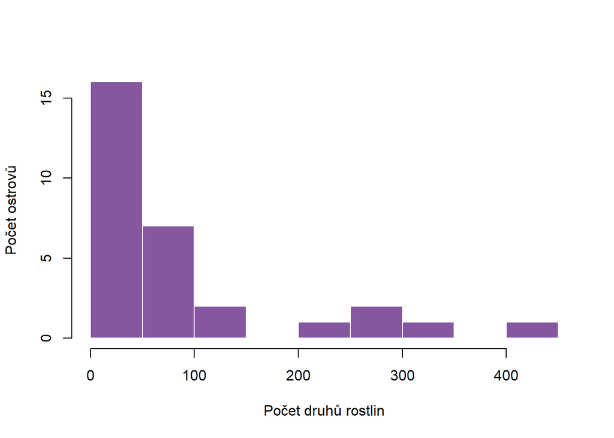

Histogram počtu druhů rostlin na 30 ostrovech.

```r
# Zobrazíme rozdělení počtu druhů
hist(
  x = data_ostrovy$pocet_druhu,
  breaks = 15,
  col = "#86579E",
  border = "white",
  main = "",
  xlab = "Počet druhů rostlin",
  ylab = "Počet ostrovů"
)
```

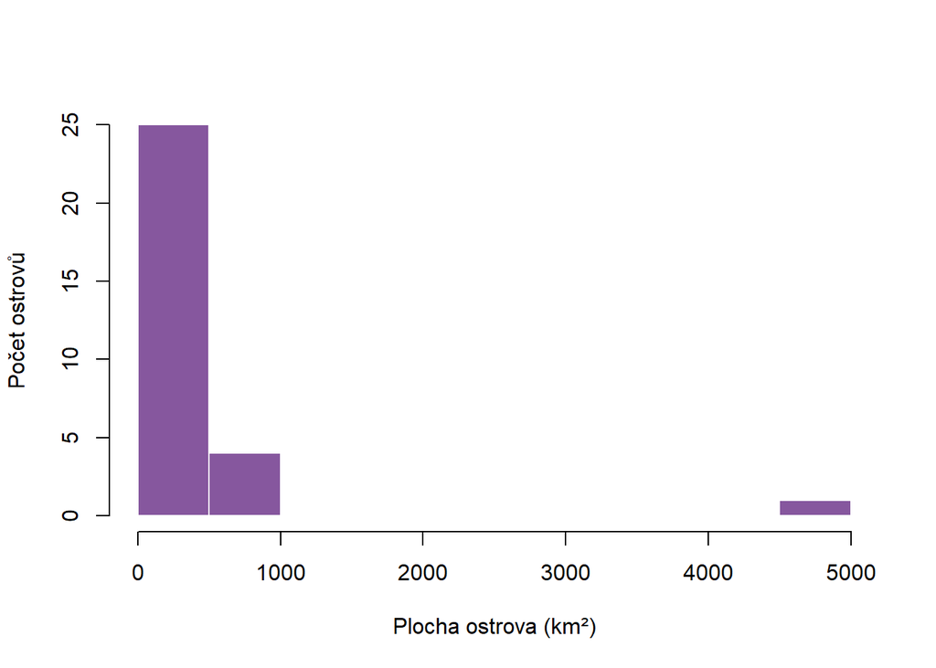

Histogram plochy 30 ostrovů.

```r
# Zobrazíme rozdělení plochy ostrovů
hist(
  x = data_ostrovy$plocha_km2,
  breaks = 15,
  col = "#86579E",
  border = "white",
  main = "",
  xlab = "Plocha ostrova (km²)",
  ylab = "Počet ostrovů"
)
```

**QuestionKde leží většina ostrovů?**

Kde v obou histogramech leží většina ostrovů? Co s obrázkem dělá několik největších ostrovů?

Většina ostrovů je malá a má málo druhů: 17 z 30 ostrovů má plochu menší než 10 km² a 23 ostrovů má méně než 100 druhů. Několik velkých ostrovů vytváří na pravé straně histogramu dlouhý řídký „chvost“. U plochy je to extrémní: téměř všechny ostrovy se vejdou do prvního koše a celý zbytek osy zabírá jen hrstka obrů. **Histogram plochy tak o malých ostrovech neříká téměř nic.**

## 3.4 Jak popsat tvar rozdělení slovy?

Pro takové obrázky potřebujeme slova. Tvar rozděleníPopis toho, jaké hodnoty proměnná nabývá a jak často se vyskytují; může jít o pozorované rozdělení dat nebo o teoretické pravděpodobnostní rozdělení. popisujeme podle několika vlastností:

- **Souměrnost.** Levá a pravá polovina rozdělení vypadají přibližně jako zrcadlový obraz.
- **ŠikmostNesouměrnost rozdělení: u pravostranně šikmého rozdělení se hodnoty táhnou dlouhým chvostem vpravo k vysokým hodnotám a průměr bývá větší než medián.** (anglicky *skewness*). Krajním částem rozdělení daleko od středu říkáme, stejně jako v lekci o testování hypotéz, **chvosty rozdělení**. U šikmého rozdělení je jeden chvost delší než druhý. Rozdělení s dlouhým chvostem vpravo nazýváme **pravostranně šikmé** (*right-skewed*), s dlouhým chvostem vlevo **levostranně šikmé** (*left-skewed*). Šikmost pojmenováváme podle strany dlouhého chvostu, nikoli podle strany, kde leží většina hodnot.
- **Těžké chvosty** (*heavy tails*). Rozdělení je souměrné, ale velmi vzdálené hodnoty na obou stranách se objevují častěji, než bychom u souměrného zvonovitého tvaru čekali (tento referenční tvar pojmenujeme o několik kapitol dál). Stejnou vlastnost jsme v lekci o testování hypotéz viděli u t-rozděleníSouměrné rozdělení podobné normálnímu, ale s těžšími chvosty; jeho tvar určují stupně volnosti a používá se pro t-statistiku a intervaly spolehlivosti. s malým počtem stupňů volnostiPočet nezávislých informací dostupných pro odhad parametru; počet pozorování minus počet odhadovaných parametrů..
- **Vícevrcholovost** (*multimodality*). Rozdělení má dva nebo více vrcholů, například proto, že data obsahují dvě odlišné skupiny. Tak tomu bylo u délek erupcí gejzíru Old Faithful, které tvořily skupinu krátkých a skupinu dlouhých erupcí.
- **Omezení hodnot.** Některé veličiny nemohou klesnout pod nulu (plocha, počet, hmotnost) nebo leží mezi nulou a jedničkou (podíly). Hranice často tvar rozdělení ovlivňuje.

Abychom tvary viděli čistě, připravili jsme pět **simulovaných** souborů po 300 hodnotách. Nejde o skutečná měření; každý soubor jsme vytvořili tak, aby měl jeden typický tvar.

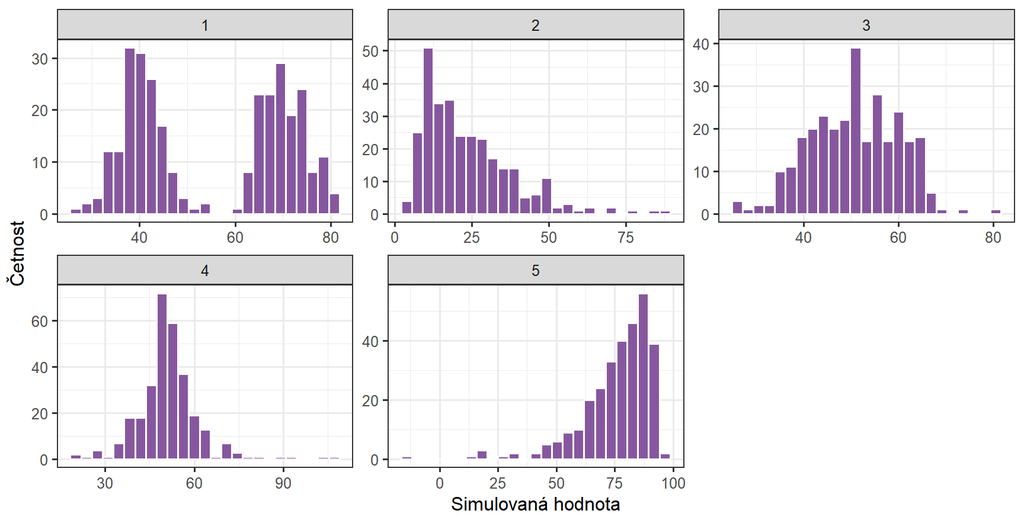

Pět simulovaných rozdělení 1–5. Každý panel má vlastní vodorovnou osu.

**QuestionPřiřaďte tvary**

Přiřaďte panelům 1–5 slova *souměrné*, *pravostranně šikmé*, *levostranně šikmé*, *těžké chvosty* a *dva vrcholy*.

**DůležitéŘešení**

1 = dva vrcholy, 2 = pravostranně šikmé, 3 = souměrné, 4 = těžké chvosty, 5 = levostranně šikmé. Panel 4 se od panelu 3 liší hlavně ojedinělými hodnotami daleko od středu; jeho střed je naopak užší.

Počet druhů i plocha ostrovů jsou tedy **pravostranně šikmé**: většina hodnot leží vlevo a dlouhý chvost míří doprava. U plochy je šikmost extrémní.

Šikmost poznáme i bez obrázku, porovnáním průměruSoučet hodnot vydělený jejich počtem; nejběžnější míra polohy (střední hodnoty). a mediánuHodnota rozdělující seřazená data na dvě stejně početné poloviny; 50% kvantil (prostřední kvartil).. V první lekci jsme u tělesné hmotnosti savců viděli, že dlouhý chvost táhne průměr k sobě, zatímco medián zůstává uprostřed seřazených hodnot. Tehdy jsme taková data nazývali „výrazně asymetrická“; přesnější název je **pravostranně šikmá**. Průměrný počet druhů je 85.2, medián jen 42. Průměrná plocha je 261.7 km², medián 2.59 km². **Průměr plochy tak popisuje ostrov, jakých je v souostroví jen několik.**

**TipDoplňující: Jak šikmost vyjádřit jedním číslem?**

Šikmost lze shrnout jedním číslem, **koeficientem šikmosti**. Pro každou hodnotu spočítáme odchylku od průměru, vydělíme ji směrodatnou odchylkouOdmocnina rozptylu; vyjadřuje typickou vzdálenost hodnot od průměru ve stejných jednotkách jako původní data. a výsledek umocníme na třetí. Třetí mocnina zachová znaménko, takže dlouhý chvost vpravo převáží kladnými hodnotami a dlouhý chvost vlevo zápornými. Koeficient je průměr těchto třetích mocnin:

$$\text{koeficient šikmosti} =
\text{průměr z }\left(\frac{\text{hodnota} - \text{průměr}}{\text{směrodatná odchylka}}\right)^3.$$

```r
# Koeficient šikmosti počtu druhů
vec_druhy <- data_ostrovy$pocet_druhu

mean(
  x = ((vec_druhy - mean(x = vec_druhy)) / sd(x = vec_druhy))^3
)
```

```
[1] 1.707024
```

Koeficient šikmosti tří proměnných ostrovů.

| Proměnná | Koeficient šikmosti |
| --- | --- |
| Počet druhů | 1.71 |
| Plocha ostrova | 4.42 |
| Nejvyšší bod | 1.44 |

Kladné hodnoty odpovídají pravostranné šikmosti, záporné levostranné, hodnoty blízko nuly přibližně souměrnému tvaru. Číslo je užitečné pro stručný popis, **ale neexistuje hranice, od které by šikmost „vadila“**. O tom, zda tvar pro model něco znamená, rozhoduje graf, otázka a to, kterých hodnot se tvar týká. V literatuře najdete i varianty vzorce, které se pro malé výběry mírně liší.

## 3.5 Proč je tolik biologických veličin pravostranně šikmých?

Pravostranná šikmostNesouměrnost rozdělení: u pravostranně šikmého rozdělení se hodnoty táhnou dlouhým chvostem vpravo k vysokým hodnotám a průměr bývá větší než medián. není u biologických dat výjimkou, ale pravidlem. Plochy, hmotnosti, koncentrace, velikosti populací nebo počty druhů bývají šikmé ze dvou důvodů.

**Hranice v nule.** Plocha ani počet druhů nemohou být záporné. Když je většina hodnot blízko nule, rozděleníPopis toho, jaké hodnoty proměnná nabývá a jak často se vyskytují; může jít o pozorované rozdělení dat nebo o teoretické pravděpodobnostní rozdělení. se nemá kam rozšířit doleva, ale doprava ano.

**Růst násobením.** Mnoho biologických procesů nepřičítá stále stejný přírůstek, ale násobí. Populace roste o určité procento, buňka se dělí, strom přirůstá úměrně své velikosti. SimulaceOpakované vytváření umělých dat podle známého modelu na počítači; ukazuje, jak se odhady, intervaly nebo testy chovají napříč mnoha výběry. v následujícím obrázku ukazuje rozdíl. Celkem 1000 simulovaných populací začíná na stejné velikosti a 20krát se změní. Vlevo se v každém kroku k velikosti přičte náhodný přírůstek, vpravo se velikost vynásobí náhodným faktorem.

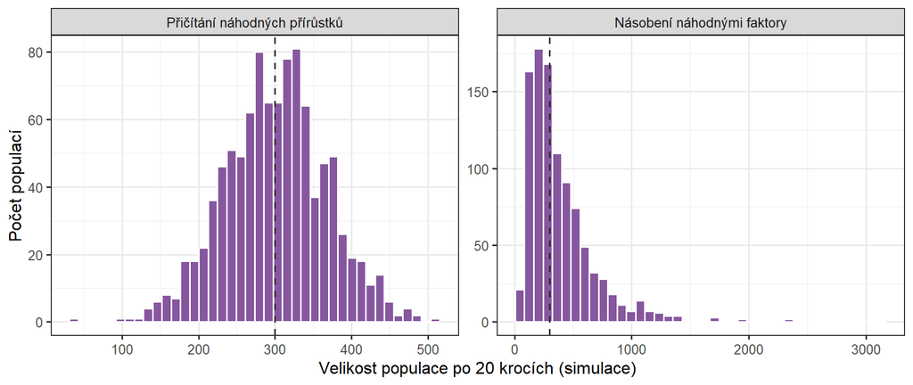

Simulované velikosti 1000 populací po 20 náhodných změnách. Vlevo se přírůstky přičítají, vpravo se velikost násobí.

Když se sčítá mnoho malých náhodných vlivů, kladné a záporné přírůstky se navzájem vyrovnávají a vzniká souměrný zvon. Když se náhodné vlivy násobí, populace, které už jsou velké, rostou ve stejných procentech o mnohem více jedinců než malé. Několik populací proto uteče daleko doprava a vznikne pravostranně šikmé rozdělení.

Na Galapágách se na šikmosti plochy podílí hlavně hranice v nule: malých ostrůvků a skalek je mnoho, velkých sopečných ostrovů jen několik a plocha nemůže klesnout pod nulu. Šikmý počet druhů pak zčásti kopíruje šikmou plochu, protože větší ostrovy nabízejí více prostředí pro více druhů. **Šikmost tedy sama o sobě není chybou dat. Je to vlastnost biologie, kterou musíme znát a zohlednit při volbě modelu.**

## 3.6 K čemu slouží normální rozdělení?

Souměrný zvon z levého panelu simulace už známe. V předchozích lekcích jsme jej používali jako referenční tvar v Q–Q grafechGraf, který porovnává seřazené hodnoty (typicky residua) s kvantily očekávanými u zvoleného rozdělení, nejčastěji normálního. residuíRozdíl mezi pozorovanou hodnotou odezvy a hodnotou odhadnutou modelem: eᵢ = yᵢ − ŷᵢ. a podobný tvar má také t-rozděleníSouměrné rozdělení podobné normálnímu, ale s těžšími chvosty; jeho tvar určují stupně volnosti a používá se pro t-statistiku a intervaly spolehlivosti., ze kterého jsme počítali p-hodnotyPravděpodobnost, že bychom při platnosti nulové hypotézy pozorovali data alespoň tak extrémní jako naše skutečná data. a intervaly spolehlivostiRozsah hodnot vypočtený z dat postupem, který při opakovaných výběrech pokryje skutečnou hodnotu parametru ve zvoleném podílu případů (typicky 95 %).. Tento zvonovitý tvar se nazývá **normální rozděleníSouměrné zvonovité pravděpodobnostní rozdělení určené průměrem a směrodatnou odchylkou; lineární model předpokládá přibližně normální rozdělení residuí.** (anglicky *normal distribution*, také Gaussovo rozdělení).

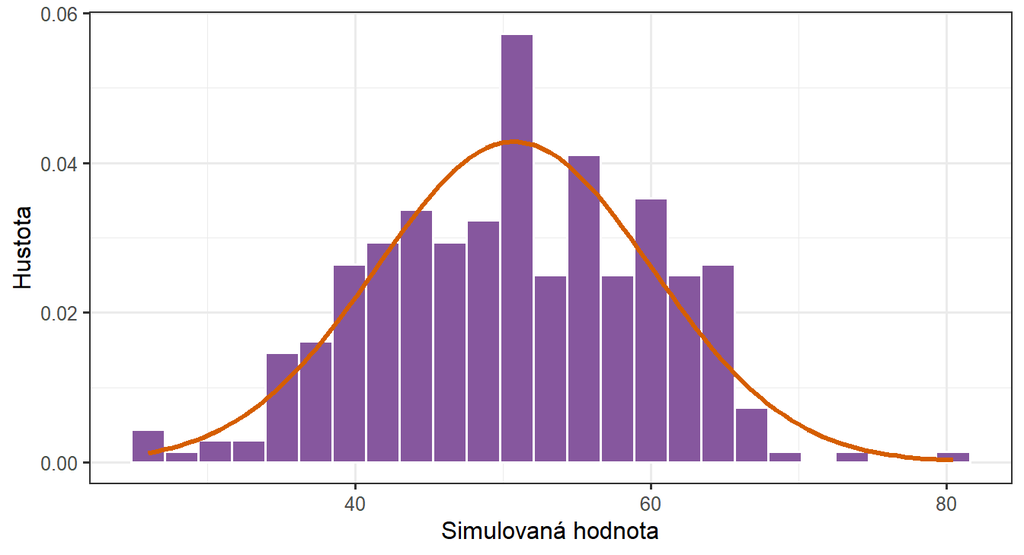

Simulovaný souměrný soubor 3 z galerie tvarů a křivka normálního rozdělení se stejným průměrem a směrodatnou odchylkou.

Normální rozdělení je souměrné a má jeden vrchol. Jeho tvar určují jen dvě čísla, která známe už z první lekce: průměrSoučet hodnot vydělený jejich počtem; nejběžnější míra polohy (střední hodnoty). a směrodatná odchylkaOdmocnina rozptylu; vyjadřuje typickou vzdálenost hodnot od průměru ve stejných jednotkách jako původní data. (SD). **Průměr říká, kde leží střed zvonu. SD říká, jak je zvon široký.**

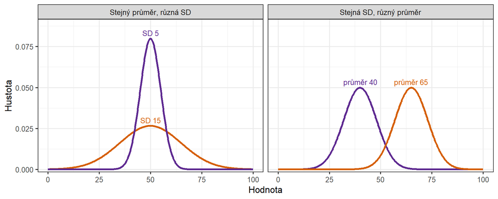

Normální rozdělení s různými průměry a směrodatnými odchylkami. Vlevo stejný průměr a různá SD, vpravo stejná SD a různý průměr.

Změna průměru posune celý zvon doleva nebo doprava, aniž by změnila jeho tvar. Větší SD zvon roztáhne do šířky, a protože plocha pod křivkou zůstává stejná, zvon zároveň sníží. Hodnoty daleko od středu jsou u normálního rozdělení vzácné. Jak vzácné, můžeme vyjádřit právě v jednotkách SD.

**QuestionKolik hodnot leží blízko průměru?**

Představte si přibližně normální veličinu, například délku křídla u velkého výběruSoubor pozorování, z něhož počítáme statistiky a pomocí něhož se snažíme popsat širší populaci nebo proces. ptáků jednoho druhu. Kolik procent jedinců odhadujete, že bude mít délku křídla nejvýš o jednu SD menší nebo větší než průměr? A kolik do dvou SD?

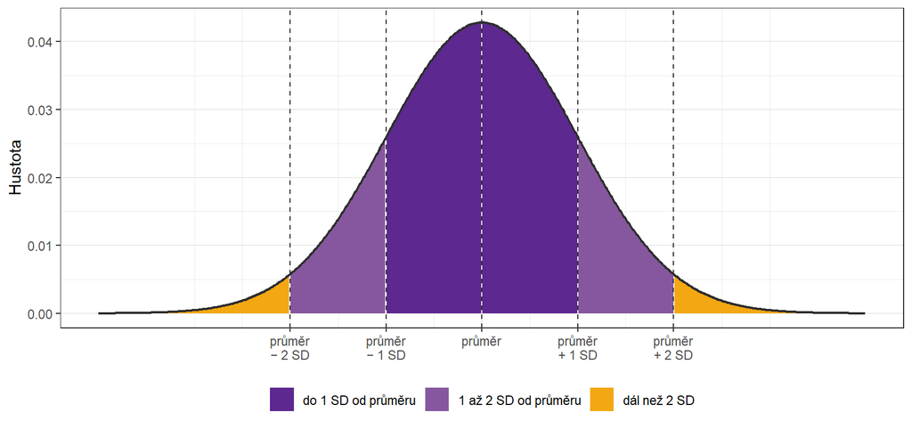

Normální rozdělení se stejným průměrem a SD jako simulovaný souměrný soubor 3. Barva ukazuje, jak daleko od průměru hodnoty leží, měřeno v SD.

**PoznámkaPrůměr a SD u normálního rozdělení**

- Přibližně 68% hodnot leží nejvýš **jednu SD** od průměru.
- Přibližně 95% hodnot leží nejvýš **dvě SD** od průměru.
- Přibližně 99.7% hodnot leží nejvýš **tři SD** od průměru; vzdálenější hodnoty jsou u normálního rozdělení velmi vzácné.

V simulovaném souměrném souboru 3 leží do jedné SD od průměru 64% hodnot a do dvou SD 97% hodnot, tedy blízko pravidlu; v souboru o 300 hodnotách se podíly od teoretických trochu liší náhodou. Podobnou myšlenku jsme použili u intervalů spolehlivosti. Odhady sklonuParametr lineárního modelu udávající, o kolik se v průměru liší odezva dvou pozorování, jejichž prediktor se liší o jednu jednotku (při stejných hodnotách ostatních prediktorů). z opakovaných výběrů kolísaly kolem skutečné hodnoty přibližně zvonovitě a jejich „směrodatnou odchylkou“ byla standardní chybaMíra přesnosti odhadu parametru (průměru, sklonu…); odhaduje z jediného výběru, jak moc by se odhady typicky lišily mezi opakovanými výběry stejné velikosti.. Proto 95% interval sahal od odhadu přibližně dvě standardní chyby na každou stranu (přesněji o kritickou hodnotuNásobitel standardní chyby použitý při konstrukci intervalu, nebo hranice testové statistiky v testu; závisí na hladině, stupních volnosti a zvoleném rozdělení. t, u malých souborů o něco větší než 2). Interval tedy nepokrývá 95 % pozorováníJeden zaznamenaný případ v datech, který obsahuje hodnoty jedné nebo více proměnných.; s 95% spolehlivostí zachycuje skutečnou hodnotu sklonu.

**U šikmých dat toto pravidlo neplatí.** Průměrná plocha ostrovů je 261.7 km² a SD 864.1 km². Průměr minus jedna SD dává -602.4 km², tedy zápornou plochu, která nemůže existovat. Do jedné SD od průměru přitom padá 97% ostrovů místo přibližně 68%. Dvojice průměr a SD tedy dobře popisuje hlavně přibližně souměrná data; proto jsme v první lekci u výrazně šikmých dat doporučili mediánHodnota rozdělující seřazená data na dvě stejně početné poloviny; 50% kvantil (prostřední kvartil). a mezikvartilové rozpětíRozdíl mezi 3. kvartilem (Q3) a 1. kvartilem (Q1); pokrývá prostředních 50 % dat a je robustní vůči odlehlým pozorováním..

**Normální rozdělení je užitečný vzor pro srovnání, nikoli výchozí vlastnost biologických dat.** Jak jsme viděli, mnoho biologických veličin normální není a ani být nemá. Normální rozdělení potřebujeme proto, že s ním lineární modelStatistický model, v němž je průměrná odezva součtem interceptu a prediktorů násobených koeficienty; lineární je v koeficientech, takže nemusí jít jen o přímku. počítá u jedné konkrétní části modelu. Kterou částí to je, zjistíme v další kapitole.

## 3.7 Jak se tvar rozdělení projeví v Q–Q grafu?

HistogramGraf zobrazující rozdělení hodnot numerické proměnné: hodnoty jsou rozděleny do sousedních intervalů (košů), výška sloupce udává četnost v daném koši. je názorný, ale u malého počtu pozorováníJeden zaznamenaný případ v datech, který obsahuje hodnoty jedné nebo více proměnných. silně závisí na volbě šířky koše (anglicky *bin width*), jak jsme viděli v první lekci. Proto jsme při kontrole residuíRozdíl mezi pozorovanou hodnotou odezvy a hodnotou odhadnutou modelem: eᵢ = yᵢ − ŷᵢ. používali Q–Q grafGraf, který porovnává seřazené hodnoty (typicky residua) s kvantily očekávanými u zvoleného rozdělení, nejčastěji normálního. (anglicky *quantile–quantile plot*). Ten porovnává seřazené hodnoty s kvantilyHodnota, pod níž leží určený podíl seřazených dat; medián je 50% kvantil., které bychom čekali u normálního rozděleníSouměrné zvonovité pravděpodobnostní rozdělení určené průměrem a směrodatnou odchylkou; lineární model předpokládá přibližně normální rozdělení residuí.. Pokud mají data normální tvar, body leží přibližně na přímce. Každý jiný tvar má svůj typický vzor odchylek.

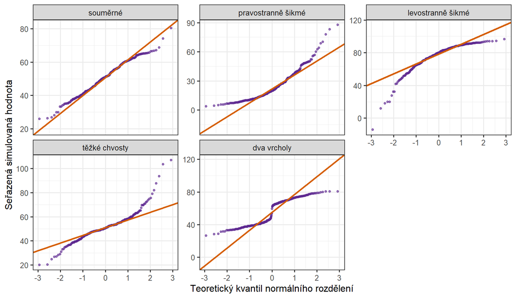

Q–Q grafy stejných pěti simulovaných souborů jako v galerii tvarů, nyní seřazené podle názvu tvaru. Přímka prochází prvním a třetím kvartilem.

**QuestionNajděte typický vzor**

Porovnejte Q–Q grafy s histogramy v galerii tvarů. Jak se v Q–Q grafu projeví dlouhý chvost vpravo? A jak dva vrcholy?

**PoznámkaJak číst odchylky v Q–Q grafu**

- **Souměrné, přibližně normální:** body leží blízko přímky, jen na krajích mírně kolísají.
- **Pravostranně šikmé:** body vpravo nahoře se zvedají nad přímku a celý graf se prohne do oblouku. Největší hodnoty jsou mnohem větší, než by normální rozdělení čekalo.
- **Levostranně šikmé:** zrcadlový obraz; body vlevo dole klesají pod přímku.
- **Těžké chvosty:** body na obou koncích se od přímky odklánějí opačnými směry, levý dolů a pravý nahoru, takže graf připomíná natažené písmeno S.
- **Dva vrcholy:** body tvoří schod, protože mezi dvěma skupinami je méně hodnot, než by normální rozdělení čekalo.

I u dokonale normálních dat body kolem přímky trochu kolísají, nejvíce na krajích. S malým počtem pozorování je toto kolísání větší. Proto hledáme **systematický vzor**, ne jednotlivé body mimo přímku.

Nový slovník pomáhá přečíst i grafy z předchozích lekcí. U residuí kosatců v lekci o první přímce se oba konce Q–Q grafu mírně odkláněly opačnými směry: residua měla **slabě těžké chvosty**.

# 4 Co lineární model předpokládá

## 4.1 Jak počet druhů popíše přímka?

Vraťme se k hlavní otázce. Nejjednodušší model, který známe, je přímka: počet druhů jako lineární funkce plochy ostrova. Vztah zobrazíme v bodovém grafuGraf vztahu dvou numerických proměnných, v němž každý bod představuje jedno pozorování a jeho dvě hodnoty určují polohu na osách. (anglicky *scatter plot*) a odhadneme lineární modelStatistický model, v němž je průměrná odezva součtem interceptu a prediktorů násobených koeficienty; lineární je v koeficientech, takže nemusí jít jen o přímku..

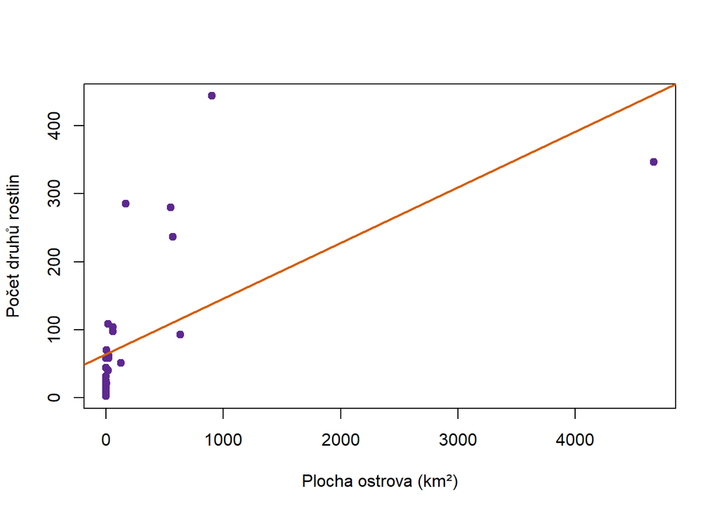

Počet druhů rostlin a plocha ostrova s odhadnutou přímkou.

```r
# Odhadneme přímku pro počet druhů podle plochy
mod_primka <-
  lm(
    formula = pocet_druhu ~ plocha_km2,
    data = data_ostrovy
  )

# Zobrazíme ostrovy a odhadnutou přímku
plot(
  x = data_ostrovy$plocha_km2,
  y = data_ostrovy$pocet_druhu,
  pch = 19,
  col = "#5D2890",
  xlab = "Plocha ostrova (km²)",
  ylab = "Počet druhů rostlin"
)

abline(
  reg = mod_primka,
  col = "#D55E00",
  lwd = 2
)
```

```r
# Vypíšeme odhadnutý intercept a sklon
coef(object = mod_primka)
```

```
(Intercept)  plocha_km2
63.78286147  0.08196317
```

Přímka říká, že každý další kilometr čtvereční přidá v průměru 0.082 druhu, tedy asi 8.2 druhu na 100 km². Obrázek ale ukazuje problém: 17 ostrovů je namačkaných u levého okraje grafu a o sklonuParametr lineárního modelu udávající, o kolik se v průměru liší odezva dvou pozorování, jejichž prediktor se liší o jednu jednotku (při stejných hodnotách ostatních prediktorů). přímky rozhoduje hlavně několik velkých ostrovů vpravo. Jak dobře přímka data popisuje, zjistíme z residuíRozdíl mezi pozorovanou hodnotou odezvy a hodnotou odhadnutou modelem: eᵢ = yᵢ − ŷᵢ.. Předtím si ale ujasníme, co přesně u nich kontrolujeme.

## 4.2 Co přesně má být u lineárního modelu normální?

Viděli jsme, že počet druhů i plocha jsou silně pravostranně šikmé. Znamená to, že lineární modelStatistický model, v němž je průměrná odezva součtem interceptu a prediktorů násobených koeficienty; lineární je v koeficientech, takže nemusí jít jen o přímku. pro tato data nelze použít? Odpověď začíná otázkou, z čeho se počet druhů jednoho ostrova podle modelu skládá.

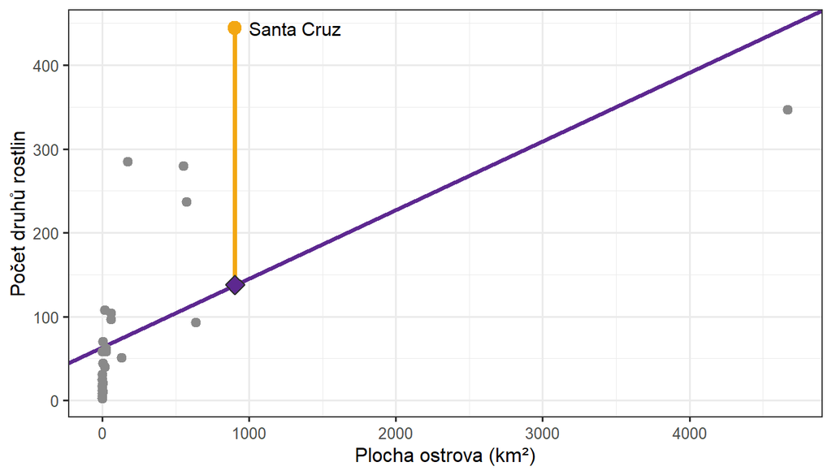

Počet druhů ostrova Santa Cruz rozložený na odhadnutou hodnotu (kosočtverec na přímce) a residuum (svislá úsečka).

Ostrov Santa Cruz má 444 druhů. Přímka pro jeho plochu odhaduje 138 druhů a zbytek, 306 druhů, je jeho residuumRozdíl mezi pozorovanou hodnotou odezvy a hodnotou odhadnutou modelem: eᵢ = yᵢ − ŷᵢ.:

$$444 = 138 + 306.$$

Totéž platí pro každý ostrov: **pozorovaná hodnota = odhadnutá hodnotaHodnota odezvy, kterou fitovaný model přiřadí pozorování na základě jeho hodnot prediktorů; značí se často ŷ. + residuum.** Přímka nese systematickou část vztahu, residuum to, co přímka nevysvětlila.

**QuestionJak by vypadala residua, kdyby přímka seděla?**

Představte si, že by přímka zachytila všechno systematické, co plocha o počtu druhů prozrazuje. Co by v residuích zbylo? Načrtněte, jak by vypadal jejich histogramGraf zobrazující rozdělení hodnot numerické proměnné: hodnoty jsou rozděleny do sousedních intervalů (košů), výška sloupce udává četnost v daném koši..

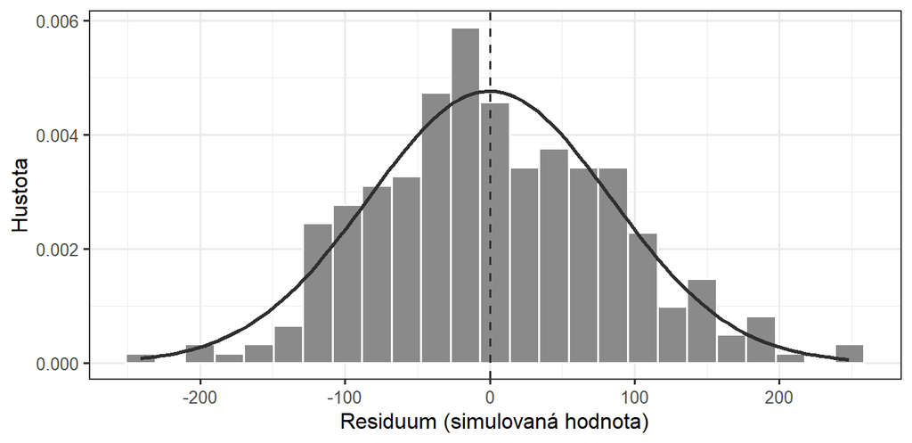

Simulace: 300 residuí přímky, která vztah vystihuje. Směrodatná odchylka je stejná jako u residuí ostrovů; tmavá křivka je normální rozdělení.

Kdyby přímka vystihovala vztah, zbyly by v residuích jen náhodné odchylky: kladné i záporné, malé častěji než velké, rozložené souměrně kolem nuly. Tvar se blíží zvonu normálního rozděleníSouměrné zvonovité pravděpodobnostní rozdělení určené průměrem a směrodatnou odchylkou; lineární model předpokládá přibližně normální rozdělení residuí. z předchozí kapitoly. **Právě takový tvar residuí lineární model předpokládá.** O tvaru samotné odezvyProměnná, jejíž variabilitu se snažíme vysvětlit nebo předpovědět; v notaci modelu y ~ x je odezva y. nebo prediktoruProměnná, pomocí níž vysvětlujeme variabilitu odezvy; v notaci y ~ x je prediktor x. přitom nic netvrdí. Ověřte si, že je to jasné:

**QuestionOvěřte si: co musí mít přibližně normální rozdělení?**

Lineární model předpokládá přibližně normální rozdělení:

1. odezvy (počtu druhů),
2. prediktoru (plochy ostrova),
3. residuí modelu,
4. odezvy i prediktoru zároveň.

**DůležitéŘešení**

**Správně je c).** Lineární model popisuje odezvu jako součet systematické části (přímky) a náhodných odchylek kolem ní. Předpoklad normality se týká právě těchto odchylek, tedy residuí.

- 1. Odezva může být šikmá, například proto, že šikmý je prediktor. Pokud model vysvětlí, proč jsou některé hodnoty velké, residua mohou být souměrná i u šikmé odezvy.
- 2. O rozděleníPopis toho, jaké hodnoty proměnná nabývá a jak často se vyskytují; může jít o pozorované rozdělení dat nebo o teoretické pravděpodobnostní rozdělení. prediktoru model nepředpokládá nic. Hodnoty prediktoru bereme jako dané.
- 4. Tento požadavek je ještě přísnější než a) a model jej nemá.

**UpozorněníČastá chyba: kontrolovat normalitu dat místo residuí**

Histogram nebo test normality samotné odezvy či prediktoru nerozhoduje o tom, zda je lineární model vhodný. Rozhodují residua odhadnutého modelu. Šikmý prediktor ani šikmá odezva samy o sobě předpoklad neporušují. Totéž jsme poprvé uvedli u přímky pro kosatce: lineární model nevyžaduje, aby samotná odezva měla normální rozdělení. Příklad modelu, jehož odezva je silně šikmá, a residua přesto vyhovující, uvidíme v části o tvaru vztahu.

**TipDoplňující: měly modely z předchozích lekcí přibližně normální residua?**

Předpoklad o tvaru residuí platil pro každý lineární model v kurzu, ale ne vždy jsme jej kontrolovali stejně důkladně. Vyzkoušejte to zpětně. Pro dva modely máme data k dispozici přímo zde.

**Kosatce (lekce o první přímce).** Model délky korunního lístku podle jeho šířky lze odhadnout z dat `iris`, která jsou součástí R.

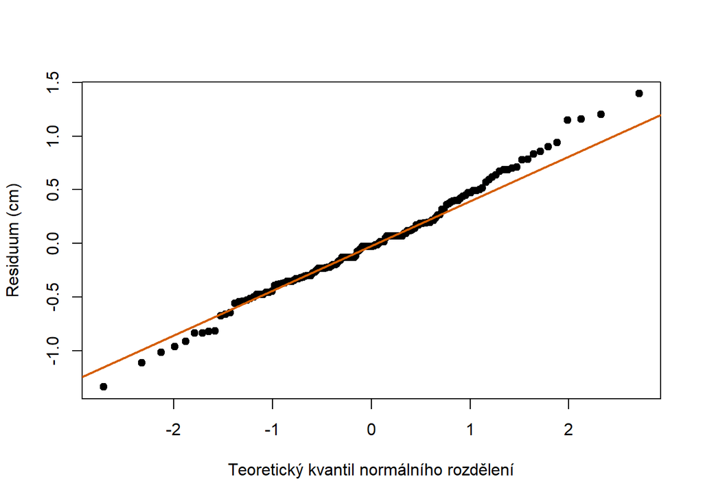

Q–Q graf residuí přímky pro kosatce z lekce o první přímce.

```r
# Model z lekce o první přímce, odhadnutý z vestavěných dat iris
mod_kosatce <-
  lm(
    formula = Petal.Length ~ Petal.Width,
    data = iris
  )

qqnorm(
  y = residuals(object = mod_kosatce),
  pch = 19,
  main = "",
  xlab = "Teoretický kvantil normálního rozdělení",
  ylab = "Residuum (cm)"
)

qqline(
  y = residuals(object = mod_kosatce),
  col = "#D55E00",
  lwd = 2
)
```

**Stromy (předchozí lekce).** Aditivní modelModel s více prediktory bez interakce: příspěvky prediktorů se sčítají, takže vztah odezvy k jednomu prediktoru je stejný při všech hodnotách ostatních. výšky stromu podle průměru kmene a druhu:

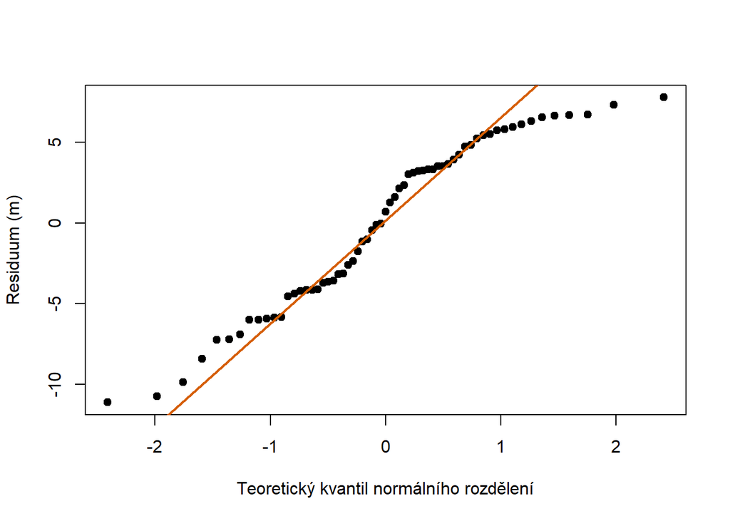

Q–Q graf residuí aditivního modelu pro stromy z předchozí lekce.

```r
# Stromy z předchozí lekce
data_stromy_kontrola <-
  read.csv(
    file = here::here("data", "allometrie_stromu.csv"),
    stringsAsFactors = TRUE
  )

mod_stromy_kontrola <-
  lm(
    formula = vyska_stromu_m ~ prumer_kmene_cm + druh_stromu,
    data = data_stromy_kontrola
  )

qqnorm(
  y = residuals(object = mod_stromy_kontrola),
  pch = 19,
  main = "",
  xlab = "Teoretický kvantil normálního rozdělení",
  ylab = "Residuum (m)"
)

qqline(
  y = residuals(object = mod_stromy_kontrola),
  col = "#D55E00",
  lwd = 2
)
```

U kosatců se konce odklánějí jen mírně. U stromů je odchylka výraznější; souvisí s obloukem v residuích, ke kterému se vrátíme na konci lekce.

**Ostatní modely zkontrolujte sami** v R skriptech z praktických cvičení příslušných lekcí. Ke každému modelu stačí doplnit `qqnorm()` a `qqline()` s jeho residui:

| Lekce | Model | Co jsme o residuích tehdy zkontrolovali | Na co se zaměřit |
| --- | --- | --- | --- |
| gejzír Old Faithful | čekání podle délky erupce | graf residuí podle odhadnutých hodnot: dvě skupiny erupcí, obě kolem nuly, a několik velkých kladných residuí | zda velká kladná residua neprodlužují pravý konec Q–Q grafu; schod by se objevil jen tehdy, kdyby residua jedné skupiny ležela soustavně výš než residua druhé |
| kraby a zeměpisná šířka | šířka krunýře podle zeměpisné šířky (průměry lokalit) | diagnostické grafy bez zřetelného vzoru, ale jen z několika lokalit | jak málo lze o tvaru říct z tak malého počtu bodů |
| tučňáci a jejich druhy | hmotnost podle druhu | Q–Q graf: body většinou na přímce | zda se konce chovají ve všech druzích podobně |
| křídlatka | tloušťka listu podle teploty a původu | graf residuí podle odhadnutých hodnot: dva shluky kolem nuly | Q–Q graf, který jsme tehdy neukázali |
| kraby a pohlaví | zadní šířka podle délky krunýře, pohlaví a jejich interakce | graf residuí podle odhadnutých hodnot | Q–Q graf, který jsme tehdy neukázali |

Nepřekvapí vás, když residua nebudou dokonale normální. Smyslem je posoudit, zda je odchylka natolik velká, aby zpochybnila nejistotu, kterou jsme v dané lekci vyvozovali.

Jak se tedy chovají residua přímky pro ostrovy?

## 4.3 Co ukazují residua přímky?

ResiduaRozdíl mezi pozorovanou hodnotou odezvy a hodnotou odhadnutou modelem: eᵢ = yᵢ − ŷᵢ. kontrolujeme stejnými grafy jako v předchozích lekcích: residui podle odhadnutých hodnotHodnota odezvy, kterou fitovaný model přiřadí pozorování na základě jeho hodnot prediktorů; značí se často ŷ., histogramemGraf zobrazující rozdělení hodnot numerické proměnné: hodnoty jsou rozděleny do sousedních intervalů (košů), výška sloupce udává četnost v daném koši. residuí a Q–Q grafemGraf, který porovnává seřazené hodnoty (typicky residua) s kvantily očekávanými u zvoleného rozdělení, nejčastěji normálního. residuí.

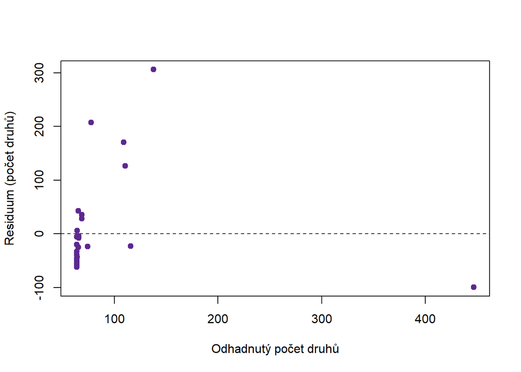

Residua přímky podle odhadnutého počtu druhů.

```r
# Residua podle odhadnutého počtu druhů
plot(
  x = fitted(object = mod_primka),
  y = residuals(object = mod_primka),
  pch = 19,
  col = "#5D2890",
  xlab = "Odhadnutý počet druhů",
  ylab = "Residuum (počet druhů)"
)

abline(
  h = 0,
  col = "#2E2E2E",
  lty = 2
)
```

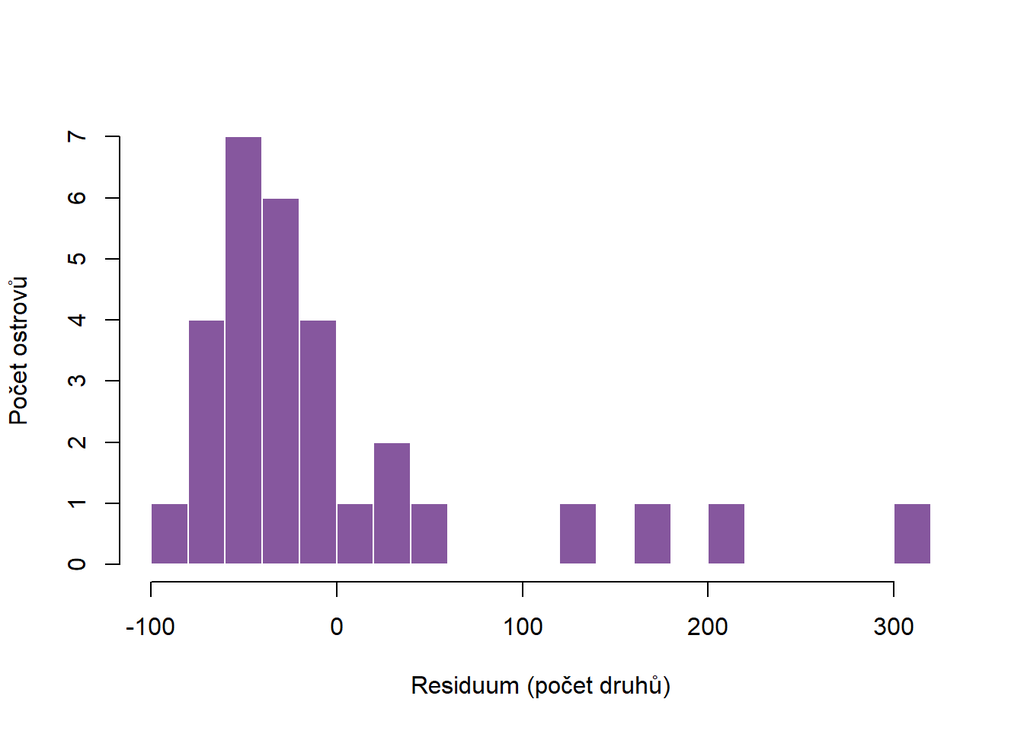

Histogram residuí přímky.

```r
# Histogram residuí přímky
hist(
  x = residuals(object = mod_primka),
  breaks = 15,
  col = "#86579E",
  border = "white",
  main = "",
  xlab = "Residuum (počet druhů)",
  ylab = "Počet ostrovů"
)
```

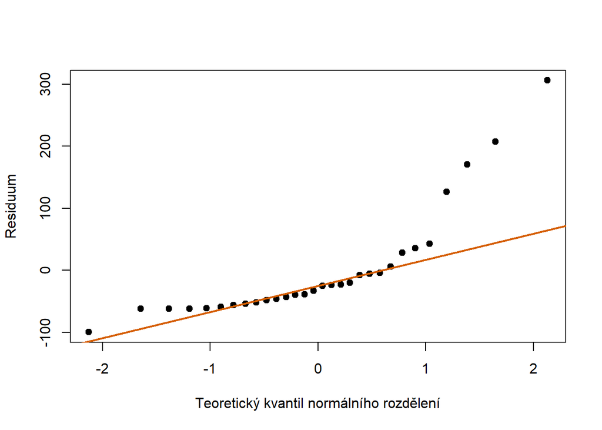

Q–Q graf residuí přímky.

```r
# Q–Q graf residuí přímky
qqnorm(
  y = residuals(object = mod_primka),
  pch = 19,
  main = "",
  xlab = "Teoretický kvantil normálního rozdělení",
  ylab = "Residuum"
)

qqline(
  y = residuals(object = mod_primka),
  col = "#D55E00",
  lwd = 2
)
```

**QuestionCo residua prozrazují?**

Najděte v obou grafech alespoň dva vzory, které by u dobře padnoucího modelu neměly být vidět.

V grafu residuí podle odhadnutých hodnot netvoří body vodorovný pás kolem nuly. Většina ostrovů je nahuštěná vlevo, kde má přímka malé odhadnuté hodnoty, a **rozptylSoučet čtverců odchylek od průměru dělený n − 1; míra variability dat. Odmocnina rozptylu je směrodatná odchylka. residuí se směrem doprava zvětšuje** (heteroskedasticitaJev, kdy rozptyl residuí není konstantní podél hodnot prediktoru - typicky se rozptýlení residuí zvětšuje s rostoucí odhadnutou hodnotou.). Histogram residuí má dlouhý chvost vpravo a Q–Q graf se vpravo prudce zvedá: několik kladných residuí je mnohem větších, než by normální rozdělení čekalo. Residua přímky jsou tedy pravostranně šikmá, nemají přibližně normální tvar a jejich rozptyl není konstantní. **Problém se netýká jen tvaru rozděleníPopis toho, jaké hodnoty proměnná nabývá a jak často se vyskytují; může jít o pozorované rozdělení dat nebo o teoretické pravděpodobnostní rozdělení., ale i tvaru vztahu: přímka nesleduje, jak se počet druhů s plochou opravdu mění.**

## 4.4 Jak jeden velký ostrov ovlivní celou přímku?

Šikmý prediktorProměnná, pomocí níž vysvětlujeme variabilitu odezvy; v notaci y ~ x je prediktor x. předpoklad modelu neporušuje, ale má praktický důsledek. Několik extrémně velkých ostrovů leží daleko od ostatních na ose x. Taková pozorováníJeden zaznamenaný případ v datech, který obsahuje hodnoty jedné nebo více proměnných. mají velký pákový efektMíra toho, jak neobvyklé hodnoty prediktorů má jedno pozorování ve srovnání s ostatními; nezávisí na naměřené odezvě. (anglicky *leverage*): přímka se k nim natáčí podobně jako dlouhá páka. Jejich vliv na odhadnuté hodnotyHodnota odezvy, kterou fitovaný model přiřadí pozorování na základě jeho hodnot prediktorů; značí se často ŷ. měří Cookova vzdálenostMíra vlivu jednoho pozorování na model: vyjadřuje, jak moc by se změnily odhadnuté hodnoty, kdybychom toto pozorování vynechali., kterou známe z předchozích lekcí.

**QuestionKterý ostrov přímku ovládá?**

Podívejte se znovu na bodový graf s přímkou. Který ostrov by podle vás po vynechání změnil přímku nejvíc a proč?

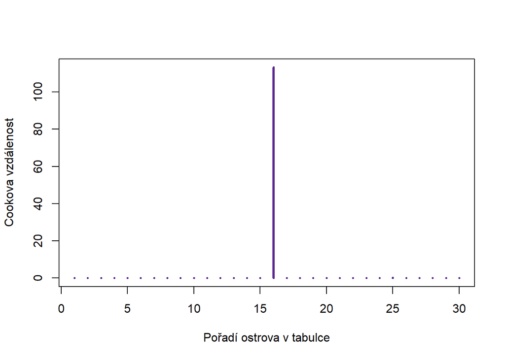

Cookovy vzdálenosti jednotlivých ostrovů v modelu přímky.

```r
# Vypočítáme vliv jednotlivých ostrovů na přímku
vec_cook_primka <-
  cooks.distance(model = mod_primka)

plot(
  x = vec_cook_primka,
  type = "h",
  lwd = 3,
  col = "#5D2890",
  xlab = "Pořadí ostrova v tabulce",
  ylab = "Cookova vzdálenost"
)
```

Ostrov Isabela má Cookovu vzdálenost 113.3, zatímco druhá nejvyšší hodnota je jen 0.32. Hodnota větší než 1 je podle všech běžných orientačních pravidel neobvykle vysoká. **SklonParametr lineárního modelu udávající, o kolik se v průměru liší odezva dvou pozorování, jejichž prediktor se liší o jednu jednotku (při stejných hodnotách ostatních prediktorů). přímky tak z velké části určuje jediný ostrov.** Ostrov přitom není chybou měření a nemáme důvod jej odstranit. Problém je v modelu: přímka neumí popsat ostrovy, jejichž plochy se liší o několik řádů.

## 4.5 Co říká test normality residuí?

Q–Q grafGraf, který porovnává seřazené hodnoty (typicky residua) s kvantily očekávanými u zvoleného rozdělení, nejčastěji normálního. posuzujeme očima. Někdy chceme odchylku od normálního tvaru shrnout také jedním číslem. K tomu slouží **test normality**, nejčastěji Shapiro–Wilkův test (*Shapiro–Wilk test*). Jak se jeho statistika počítá, nepotřebujeme; důležité je umět výsledek přečíst.

Test používá stejnou logiku jako ostatní testy v kurzu. Nulová hypotézaVýchozí předpoklad, který testujeme - typicky ‘efekt je nulový’ nebo ‘skupiny se neliší’; p-hodnota udává pravděpodobnost dat alespoň tak extrémních jako naše za předpokladu platnosti H₀. tvrdí, že residuaRozdíl mezi pozorovanou hodnotou odezvy a hodnotou odhadnutou modelem: eᵢ = yᵢ − ŷᵢ. pocházejí z normálního rozděleníSouměrné zvonovité pravděpodobnostní rozdělení určené průměrem a směrodatnou odchylkou; lineární model předpokládá přibližně normální rozdělení residuí.. P-hodnotaPravděpodobnost, že bychom při platnosti nulové hypotézy pozorovali data alespoň tak extrémní jako naše skutečná data. říká, jak neobvyklá by byla tak velká odchylka od normálního tvaru, kdyby nulová hypotéza platila.

```r
# Shapiro–Wilkův test normality residuí přímky
shapiro.test(x = residuals(object = mod_primka))
```

```
    Shapiro-Wilk normality test

data:  residuals(object = mod_primka)
W = 0.73771, p-value = 5.8e-06
```

Test vrátil p < 0.001. Kdyby residua pocházela z normálního rozdělení, tak velká odchylka by byla velmi neobvyklá. Test tedy potvrzuje to, co jsme viděli v Q–Q grafu.

**PoznámkaJak číst test normality**

- **Malá p-hodnota** znamená, že residua jen stěží pocházejí z normálního rozdělení. Neříká, jak velká odchylka je ani zda je pro naši otázku podstatná.
- **Velká p-hodnota** neznamená, že residua *jsou* normální. Znamená jen, že test odchylku neprokázal.
- Test vždy čteme **až po Q–Q grafu** a spolu s ním, nikdy místo něj.

## 4.6 Proč výsledek testu závisí na počtu pozorování?

Test normality odpovídá na otázku „lze odchylku od normálního tvaru odlišit od náhody?“, nikoli „je odchylka pro model podstatná?“. Odpověď na první otázku silně závisí na počtu pozorováníJeden zaznamenaný případ v datech, který obsahuje hodnoty jedné nebo více proměnných.. Ukážeme to simulacíOpakované vytváření umělých dat podle známého modelu na počítači; ukazuje, jak se odhady, intervaly nebo testy chovají napříč mnoha výběry.: opakovaně vytvoříme soubory residuíRozdíl mezi pozorovanou hodnotou odezvy a hodnotou odhadnutou modelem: eᵢ = yᵢ − ŷᵢ. s mírnou a se silnou pravostrannou šikmostíNesouměrnost rozdělení: u pravostranně šikmého rozdělení se hodnoty táhnou dlouhým chvostem vpravo k vysokým hodnotám a průměr bývá větší než medián. a pro každý soubor provedeme Shapiro–Wilkův test.

**QuestionPředpovězte výsledek**

Odchylka residuí od normálního tvaru bude stejná, jen se zvětší počet pozorování. Bude test takovou odchylku odhalovat častěji, nebo méně často?

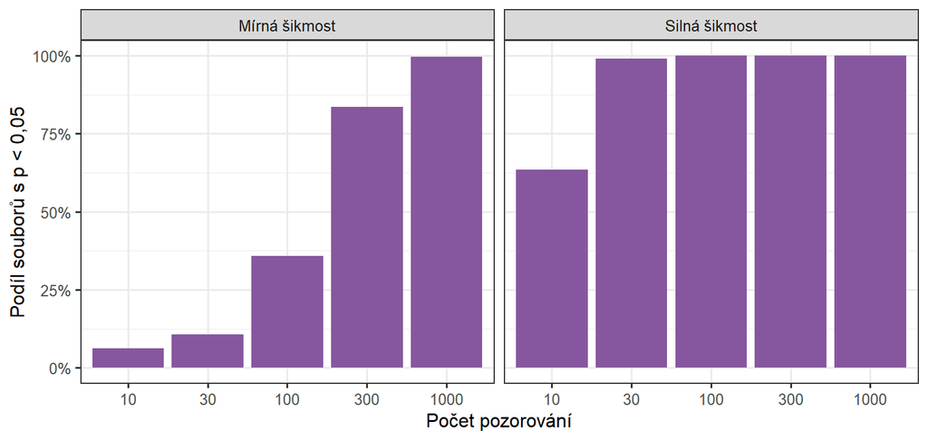

Simulace: jak často Shapiro–Wilkův test na hladině 0.05 odhalí stejnou odchylku od normálního tvaru při různém počtu pozorování (400 opakování pro každou kombinaci).

Při mírné šikmosti test odchylku odhalil jen v 11% souborů se 30 pozorováními, ale v 100% souborů s 1000 pozorováními. Silnou šikmost při 10 pozorováních odhalil jen v 64% souborů.

V lekci o první přímce jsme upozornili, že u velkého souboru může i nepatrná odchylka vypadat „statisticky zjistitelně“. Simulace tento jev ukazuje přímo. Podíl souborů, ve kterých test skutečně existující odchylku odhalí, jsme v lekci o testování nazvali **síla testuPravděpodobnost, že test zamítne nulovou hypotézu, když skutečný efekt dané velikosti existuje; je to 1 − β.**: roste s počtem pozorování a s velikostí odchylky.

Z toho plynou dvě praktická pravidla:

- **U velkých výběrůSoubor pozorování, z něhož počítáme statistiky a pomocí něhož se snažíme popsat širší populaci nebo proces.** test označí i drobné odchylky, které pro lineární modelStatistický model, v němž je průměrná odezva součtem interceptu a prediktorů násobených koeficienty; lineární je v koeficientech, takže nemusí jít jen o přímku. nemají praktický význam. U velkých výběrů navíc mírná odchylka od normálního tvaru residuí odhady sklonůParametr lineárního modelu udávající, o kolik se v průměru liší odezva dvou pozorování, jejichž prediktor se liší o jednu jednotku (při stejných hodnotách ostatních prediktorů). a intervaly spolehlivostiRozsah hodnot vypočtený z dat postupem, který při opakovaných výběrech pokryje skutečnou hodnotu parametru ve zvoleném podílu případů (typicky 95 %). obvykle téměř neovlivní; podrobné zdůvodnění přesahuje tento kurz.
- **U malých výběrů** může test nevýznamným výsledkem „propustit“ i velkou odchylku. Naše data mají jen 30 ostrovů, takže velká p-hodnotaPravděpodobnost, že bychom při platnosti nulové hypotézy pozorovali data alespoň tak extrémní jako naše skutečná data. by sama o sobě mnoho nedokazovala.

Rozhodnutí proto stojí na Q–Q grafuGraf, který porovnává seřazené hodnoty (typicky residua) s kvantily očekávanými u zvoleného rozdělení, nejčastěji normálního., na grafu residuí podle odhadnutých hodnotHodnota odezvy, kterou fitovaný model přiřadí pozorování na základě jeho hodnot prediktorů; značí se často ŷ. a na otázce, zda odchylka může změnit biologický závěr. Test je doplňující číslo, nikoli brána, kterou musí model projít.

# 5 Transformace: poloha a měřítko, nebo tvar?

Přímka selhala dvakrát: její residuaRozdíl mezi pozorovanou hodnotou odezvy a hodnotou odhadnutou modelem: eᵢ = yᵢ − ŷᵢ. mají šikmý tvar a rostoucí rozptylSoučet čtverců odchylek od průměru dělený n − 1; míra variability dat. Odmocnina rozptylu je směrodatná odchylka. a o jejím sklonuParametr lineárního modelu udávající, o kolik se v průměru liší odezva dvou pozorování, jejichž prediktor se liší o jednu jednotku (při stejných hodnotách ostatních prediktorů). rozhoduje jediný ostrov. Než začneme měnit model, podíváme se na nástroj, který ke změně potřebujeme: **transformaciMatematická operace použitá na hodnoty proměnné (např. logaritmus); mění tvar rozdělení i to, jaký vztah model popisuje, například násobný místo součtového.** proměnné. Transformace znamená, že na každou hodnotu proměnné použijeme stejný výpočet, například vynásobení stem nebo logaritmus. Uvidíme, že transformace se dělí do dvou velmi odlišných skupin.

## 5.1 Změní se tvar rozdělení, když plochu převedeme na hektary?

Nejjednodušší transformacíMatematická operace použitá na hodnoty proměnné (např. logaritmus); mění tvar rozdělení i to, jaký vztah model popisuje, například násobný místo součtového. je změna jednotek. Jeden kilometr čtvereční má 100 hektarů.

```r
# Převedeme plochu z km² na hektary
data_ostrovy$plocha_ha <-
  data_ostrovy$plocha_km2 * 100
```

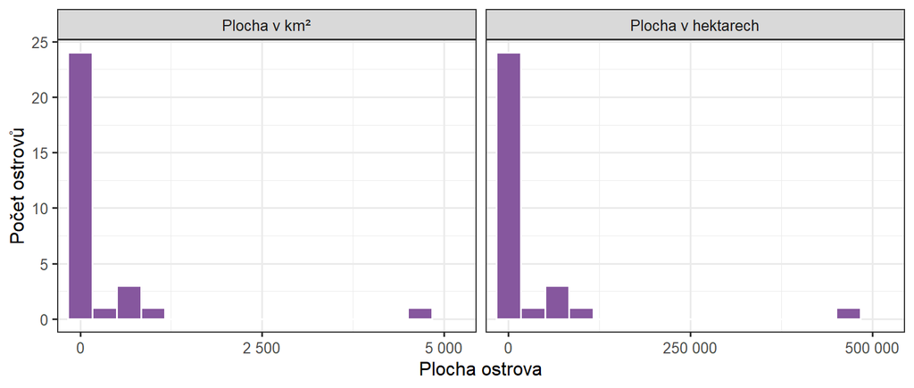

Plocha ostrovů v km² a v hektarech. Mění se jen popisky vodorovné osy.

Oba histogramyGraf zobrazující rozdělení hodnot numerické proměnné: hodnoty jsou rozděleny do sousedních intervalů (košů), výška sloupce udává četnost v daném koši. mají stejný tvar. Změnila se jen čísla na ose. Vynásobení konstantou natáhne nebo stlačí osu, ale **pořadí ostrovů ani poměry vzdáleností mezi nimi se nezmění**, a proto se nezmění ani tvar rozděleníPopis toho, jaké hodnoty proměnná nabývá a jak často se vyskytují; může jít o pozorované rozdělení dat nebo o teoretické pravděpodobnostní rozdělení..

**PoznámkaKdy měníme jednotky?**

- **Spojujeme data z různých zdrojů.** Jedna studie uvádí plochu v hektarech, druhá v km²; hmotnost jednou v gramech, jindy v kilogramech. Před společnou analýzou je musíme převést na stejné jednotky.
- **Chceme čitelný koeficient.** Přímka v části o předpokladech modelu přidávala 0.082 druhu na 1 km². Totéž vyjádřené na 100 km² (8.2 druhu) se čte snáz. Změna jednotek prediktoruProměnná, pomocí níž vysvětlujeme variabilitu odezvy; v notaci y ~ x je prediktor x. změní sklonParametr lineárního modelu udávající, o kolik se v průměru liší odezva dvou pozorování, jejichž prediktor se liší o jednu jednotku (při stejných hodnotách ostatních prediktorů). stejným násobkem, ale nezmění žádný závěr modelu.

## 5.2 Co se změní, když od plochy odečteme průměr?

Druhou jednoduchou transformacíMatematická operace použitá na hodnoty proměnné (např. logaritmus); mění tvar rozdělení i to, jaký vztah model popisuje, například násobný místo součtového. je **centrováníOdečtení průměru (nebo jiné zvolené hodnoty) od všech hodnot proměnné; posune polohu, ale nezmění tvar rozdělení ani rozptyl.** (anglicky *centring*): od každé hodnoty odečteme průměrSoučet hodnot vydělený jejich počtem; nejběžnější míra polohy (střední hodnoty).. Centrovaná plocha říká, o kolik km² je ostrov větší nebo menší než průměrný ostrov.

**QuestionKterý koeficient se změní?**

Odhadneme stejnou přímku jednou s původní a jednou s centrovanou plochou. Změní se po centrování sklonParametr lineárního modelu udávající, o kolik se v průměru liší odezva dvou pozorování, jejichž prediktor se liší o jednu jednotku (při stejných hodnotách ostatních prediktorů)., interceptParametr modelu: odhadnutá hodnota odezvy, když jsou všechny numerické prediktory rovny nule a kategoriální prediktory jsou v referenční skupině; geometricky jde o úsek na ose y., nebo oba koeficienty?

```r
# Od plochy každého ostrova odečteme průměrnou plochu
data_ostrovy$plocha_centrovana <-
  data_ostrovy$plocha_km2 - mean(x = data_ostrovy$plocha_km2)

# Odhadneme stejnou přímku s centrovanou plochou
mod_primka_centrovana <-
  lm(
    formula = pocet_druhu ~ plocha_centrovana,
    data = data_ostrovy
  )

# Porovnáme koeficienty obou přímek
coef(object = mod_primka)
```

```
(Intercept)  plocha_km2
63.78286147  0.08196317
```

```r
coef(object = mod_primka_centrovana)
```

```
      (Intercept) plocha_centrovana
      85.23333333        0.08196317
```

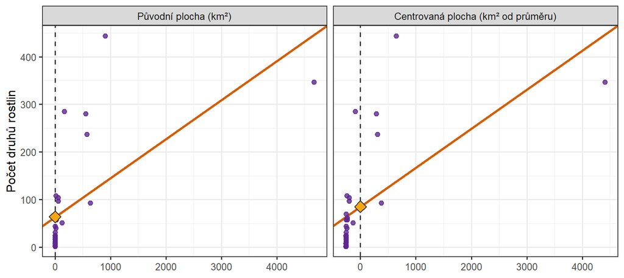

Stejná přímka nad původní a nad centrovanou plochou. Svislá přerušovaná čára označuje nulu na vodorovné ose; kosočtverec je intercept, tedy výška přímky v této nule.

Body i přímka jsou v obou panelech stejné; centrování jen posune osu tak, že nula leží v průměru. Tvar rozděleníPopis toho, jaké hodnoty proměnná nabývá a jak často se vyskytují; může jít o pozorované rozdělení dat nebo o teoretické pravděpodobnostní rozdělení. zůstane stejný. V modelu se **sklon nezmění** (v obou modelech je 0.0820), protože jeden km² navíc znamená totéž bez ohledu na to, odkud plochu měříme. **Změní se význam interceptu.** V původním modelu je intercept 63.8 odhadnutým počtem druhů na ostrově s nulovou plochou, tedy na ostrově, který neexistuje. V centrovaném modelu je intercept 85.2 odhadnutým počtem druhů na ostrově s průměrnou plochou 261.7 km². U přímky odhadnuté metodou nejmenších čtvercůPostup, který volí koeficienty modelu tak, aby byl součet čtverců residuí (RSS) co nejmenší; takto odhaduje koeficienty funkce lm(). se tato hodnota rovná průměrnému počtu druhů.

**PoznámkaKdy centrujeme?**

- **Intercept by jinak popisoval nesmysl.** V lekci o interakcích jsme narazili na to, že koeficient pohlaví u krabů se vztahoval k délce krunýře 0 mm, tedy mimo data. Po centrování délky by popisoval rozdíl mezi pohlavími u kraba průměrné délky.
- **PrediktorProměnná, pomocí níž vysvětlujeme variabilitu odezvy; v notaci y ~ x je prediktor x. je letopočet nebo nadmořská výška.** Trend „od roku 0“ nebo počet druhů „u hladiny moře“ často nemají biologický smysl. Odečteme proto smysluplnou referenční hodnotu: průměr, začátek sledování nebo průměrnou nadmořskou výšku lokalit.
- **Model obsahuje interakciSituace, kdy efekt jednoho prediktoru na odezvu závisí na hodnotě jiného prediktoru..** Hlavní koeficienty se pak vztahují k nulové hodnotě druhé proměnné; po centrování ke středu dat, kde se nejsnáze vysvětlují.

Centrování se proto hodí, když chceme, aby intercept popisoval smysluplnou, typickou hodnotu prediktoru.

## 5.3 Jak daleko od průměru leží ostrov?

Třetí transformaceMatematická operace použitá na hodnoty proměnné (např. logaritmus); mění tvar rozdělení i to, jaký vztah model popisuje, například násobný místo součtového. spojuje centrováníOdečtení průměru (nebo jiné zvolené hodnoty) od všech hodnot proměnné; posune polohu, ale nezmění tvar rozdělení ani rozptyl. se změnou jednotek. Odchylku od průměruSoučet hodnot vydělený jejich počtem; nejběžnější míra polohy (střední hodnoty). nevyjádříme v km² nebo metrech, ale v počtu směrodatných odchylekOdmocnina rozptylu; vyjadřuje typickou vzdálenost hodnot od průměru ve stejných jednotkách jako původní data.. Výsledek se nazývá **z-skóreHodnota převedená na počet směrodatných odchylek od průměru: z = (x − průměr) / SD; mění polohu a měřítko, ne tvar rozdělení.** (anglicky *z-score*) a převod na z-skóre **standardizace**.

Myšlenku už známe: t-statistikaTestová statistika: rozdíl odhadu od hodnoty v nulové hypotéze (obvykle 0) vydělený standardní chybou; říká, o kolik standardních chyb je odhad od nuly. v předchozích lekcích také měřila vzdálenost odhadu od nulové hodnoty v jednotkách jeho standardní chybyMíra přesnosti odhadu parametru (průměru, sklonu…); odhaduje z jediného výběru, jak moc by se odhady typicky lišily mezi opakovanými výběry stejné velikosti.. Z-skóre dělá totéž s jednotlivou hodnotou. Slovy:

$$\text{z-skóre} =
\frac{\text{hodnota} - \text{průměr}}{\text{směrodatná odchylka}}.$$

Spočítejme z-skóre nejvyššího bodu ostrova Fernandina. Průměr a směrodatnou odchylku počítáme z 24 ostrovů, u kterých je nejvyšší bod známý.

Od nejvyššího bodu ostrova Fernandina k jeho z-skóre (SD = směrodatná odchylka).

| Veličina | Fernandina | Průměr | Odchylka | SD | z |
| --- | --- | --- | --- | --- | --- |
| Nejvyšší bod (m n. m.) | 1494 | 424.46 | 1069.54 | 452.96 | 2.36 |

Do slovního vzorce dosadíme hodnoty z tabulky:

$$\begin{align}
\text{z-skóre výšky Fernandiny}
&= \frac{1494 - 424.46}{452.96} \\
&= \frac{1069.54}{452.96} \\
&= 2.36.
\end{align}$$

Nejvyšší bod Fernandiny leží 2.36 směrodatné odchylky nad průměrem ostrovů. Obecně pro hodnotu $x_i$ píšeme:

$$z_i = \frac{x_i - \bar{x}}{s}.$$

Symbol $z_i$ je z-skóre $i$-tého pozorováníJeden zaznamenaný případ v datech, který obsahuje hodnoty jedné nebo více proměnných., $x_i$ jeho původní hodnota, $\bar{x}$ průměr všech hodnot a $s$ jejich směrodatná odchylka. Kladné z-skóre znamená hodnotu nad průměrem, záporné pod průměrem a z-skóre 0 přesně průměr. U přibližně normální proměnné proto podle pravidla z kapitoly o normálním rozděleníSouměrné zvonovité pravděpodobnostní rozdělení určené průměrem a směrodatnou odchylkou; lineární model předpokládá přibližně normální rozdělení residuí. leží asi 95% z-skóre mezi −2 a 2.

**QuestionSpočítejte z-skóre plochy**

Fernandina má plochu 634.49 km². Průměrná plocha ostrovů je 261.71 km² a směrodatná odchylka ploch 864.11 km². Spočítejte z-skóre plochy Fernandiny.

**DůležitéŘešení**

$$\frac{634.49 - 261.71}{864.11}
= \frac{372.78}{864.11}
= 0.43.$$

Plocha Fernandiny leží 0.43 směrodatné odchylky nad průměrnou plochou.

V R lze z-skóre spočítat přímo podle vzorce, nebo funkcí `scale()`:

```r
# z-skóre nejvyššího bodu podle vzorce
data_ostrovy$vyska_z <-
  (data_ostrovy$nejvyssi_bod_m -
    mean(x = data_ostrovy$nejvyssi_bod_m, na.rm = TRUE)) /
  sd(x = data_ostrovy$nejvyssi_bod_m, na.rm = TRUE)

# Stejný výsledek funkcí scale(); as.numeric() odstraní pomocné atributy
data_ostrovy$vyska_z_scale <-
  as.numeric(x = scale(x = data_ostrovy$nejvyssi_bod_m))

# Porovnáme oba výpočty u prvních ostrovů
head(
  x = data_ostrovy[, c("ostrov", "vyska_z", "vyska_z_scale")],
  n = 4
)
```

```
     ostrov    vyska_z vyska_z_scale
1    Baltra         NA            NA
2 Bartolome -0.6964372    -0.6964372
3  Caldwell -0.6853987    -0.6853987
4  Champion -0.8355222    -0.8355222
```

```r
# Průměr a směrodatná odchylka všech z-skóre
round(
  x = mean(x = data_ostrovy$vyska_z, na.rm = TRUE),
  digits = 10
)
```

```
[1] 0
```

```r
sd(x = data_ostrovy$vyska_z, na.rm = TRUE)
```

```
[1] 1
```

Když převedeme na z-skóre **všechny hodnoty proměnné**, má výsledná proměnná vždy průměr 0 a směrodatnou odchylku 1. Průměr je nulový, protože jsme od každé hodnoty odečetli původní průměr, a směrodatná odchylka je 1, protože jsme každou odchylku vydělili původní směrodatnou odchylkou. Z-skóre tedy všechny proměnné převádí na stejnou „měrnou jednotku“: počet směrodatných odchylek od průměru.

## 5.4 Je Fernandina výjimečnější plochou, nebo výškou?

Z-skóre nemá jednotky. Díky tomu můžeme porovnat, jak neobvyklá je hodnota u veličin měřených v úplně jiných jednotkách. Plochu v km² a výšku v metrech přímo porovnat nelze; jejich z-skóre ano.

Nejvyšší bod Fernandiny leží 2.36 směrodatné odchylkyOdmocnina rozptylu; vyjadřuje typickou vzdálenost hodnot od průměru ve stejných jednotkách jako původní data. nad průměrnou výškou, její plocha jen 0.43 směrodatné odchylky nad průměrnou plochou. Podle z-skóre by tedy byla výjimečná výškou, ale plochou spíš průměrná.

Pořadí ostrovů ale ukazuje něco jiného: plochou je Fernandina 3. největší a výškou 2. nejvyšší ostrov souostroví. Výjimečná je tedy v obou ohledech.

**UpozorněníZ-skóre u šikmé veličiny klame**

PrůměrSoučet hodnot vydělený jejich počtem; nejběžnější míra polohy (střední hodnoty). i směrodatná odchylka jsou citlivé na odlehlá pozorováníPozorování, které se výrazně odlišuje od ostatních - v hodnotě jedné proměnné, nebo v modelu velkým residuem; může jít o chybu měření i o skutečně neobvyklý případ.. Obrovská plocha Isabely zvětšila směrodatnou odchylku ploch natolik, že i 3. největší ostrov vypadá v z-skóre téměř průměrně a většina ostrovů má z-skóre plochy těsně pod nulou. **Z-skóre je užitečné hlavně u přibližně souměrných veličin.** U silně šikmé veličiny samo z-skóre nestačí.

**TipDoplňující: z-skóre v korelaci a v modelu**

Při výpočtu Pearsonovy korelaceBezrozměrné číslo popisující směr a těsnost vztahu dvou proměnných; Pearsonova korelace shrnuje lineární vztah a Spearmanova monotónní vztah podle pořadí. jsme dělili součet součinů odchylek odmocninami součtů čtverců odchylek obou proměnných. Jednodušeji to vyjádříme takto: **Pearsonova korelace je průměrný součin z-skóre obou proměnných** (s dělením $n - 1$ místo $n$, stejně jako u směrodatné odchylky). Protože z-skóre nemá jednotky, nemá je ani korelace. A protože změna jednotek ani centrování z-skóre nezmění, nezmění ani korelaci.

Z-skóre lze použít i v modelu: pokud před odhadem standardizujeme prediktoryProměnná, pomocí níž vysvětlujeme variabilitu odezvy; v notaci y ~ x je prediktor x., jejich sklonyParametr lineárního modelu udávající, o kolik se v průměru liší odezva dvou pozorování, jejichž prediktor se liší o jednu jednotku (při stejných hodnotách ostatních prediktorů). udávají změnu odezvyProměnná, jejíž variabilitu se snažíme vysvětlit nebo předpovědět; v notaci modelu y ~ x je odezva y. při posunu o jednu směrodatnou odchylku. Takové *standardizované koeficienty* usnadňují porovnání prediktorů měřených v různých jednotkách. Neříkají ale samy o sobě, který prediktor je biologicky důležitější.

```r
# Pearsonova korelace plochy a počtu druhů
cor(
  x = data_ostrovy$plocha_km2,
  y = data_ostrovy$pocet_druhu
)
```

```
[1] 0.6178431
```

```r
# Stejná korelace s plochou v hektarech
cor(
  x = data_ostrovy$plocha_ha,
  y = data_ostrovy$pocet_druhu
)
```

```
[1] 0.6178431
```

```r
# Stejné číslo jako součet součinů z-skóre vydělený n - 1
sum(
  scale(x = data_ostrovy$plocha_km2) *
    scale(x = data_ostrovy$pocet_druhu)
) / (nrow(x = data_ostrovy) - 1)
```

```
[1] 0.6178431
```

**PoznámkaKdy používáme z-skóre?**

- **Porovnáváme, jak neobvyklá je hodnota u veličin v různých jednotkách**, například zda je jedinec výjimečný spíš hmotností, nebo délkou křídla.
- **Skládáme několik veličin do jednoho ukazatele.** Chceme-li například shrnout teplotu, srážky a nadmořskou výšku lokalit do jednoho „gradientu prostředí“, převedeme je nejprve na z-skóre, aby žádná veličina nepřevážila jen kvůli svým jednotkám.
- **Porovnáváme sklony prediktorů v různých jednotkách** pomocí standardizovaných koeficientů (doplňující rámeček „z-skóre v korelaci a v modelu“ výše).
- Vždy pamatujeme, že u silně šikmých veličin z-skóre klame (rámeček „Z-skóre u šikmé veličiny klame“).

## 5.5 Odstraní z-skóre šikmost?

**QuestionPředpovězte tvar**

Plocha ostrovů je extrémně pravostranně šikmá. Bude histogramGraf zobrazující rozdělení hodnot numerické proměnné: hodnoty jsou rozděleny do sousedních intervalů (košů), výška sloupce udává četnost v daném koši. z-skóreHodnota převedená na počet směrodatných odchylek od průměru: z = (x − průměr) / SD; mění polohu a měřítko, ne tvar rozdělení. plochy souměrnější?

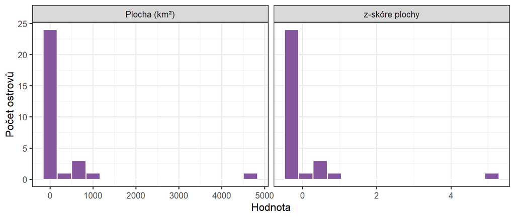

Plocha ostrovů v km² a její z-skóre.

Nebude. Histogram z-skóre má přesně stejný tvar jako histogram plochy. (Kdo četl doplňující rámeček o koeficientu šikmostiNesouměrnost rozdělení: u pravostranně šikmého rozdělení se hodnoty táhnou dlouhým chvostem vpravo k vysokým hodnotám a průměr bývá větší než medián.: ten je před standardizací 4.42 a po ní 4.42.)

**PoznámkaTransformace, které mění jen polohu a měřítko**

Změna jednotek, centrováníOdečtení průměru (nebo jiné zvolené hodnoty) od všech hodnot proměnné; posune polohu, ale nezmění tvar rozdělení ani rozptyl. i z-skóre jsou **lineární transformaceMatematická operace použitá na hodnoty proměnné (např. logaritmus); mění tvar rozdělení i to, jaký vztah model popisuje, například násobný místo součtového.**: každou hodnotu vynásobí stejným číslem a/nebo k ní přičtou stejné číslo. Posunou a natáhnou osu, ale **tvar rozděleníPopis toho, jaké hodnoty proměnná nabývá a jak často se vyskytují; může jít o pozorované rozdělení dat nebo o teoretické pravděpodobnostní rozdělení. nezmění**. Šikmost, těžké chvosty i dva vrcholy po nich zůstanou. Hodí se pro změnu významu interceptuParametr modelu: odhadnutá hodnota odezvy, když jsou všechny numerické prediktory rovny nule a kategoriální prediktory jsou v referenční skupině; geometricky jde o úsek na ose y. nebo pro porovnání veličin v různých jednotkách, nikoli pro opravu tvaru.

## 5.6 Jak logaritmus převádí násobky na stejné kroky?

Na začátku kurzu jsme logaritmickou osuŠkála, na níž stejné vzdálenosti odpovídají stejným násobkům (např. 1, 10, 100); hodí se pro hodnoty rozprostřené přes několik řádů a pro násobné vztahy. použili, když se hodnoty v grafu lišily o několik řádů. Na takové ose leží 1, 10, 100 a 1 000 ve stejných vzdálenostech: každý krok o stejnou délku znamená vynásobení desíti. Logaritmus dělá totéž s čísly. V první lekci jsme zdůraznili, že logaritmická osa mění jen rozestupy na grafu a průměrSoučet hodnot vydělený jejich počtem; nejběžnější míra polohy (střední hodnoty). i mediánHodnota rozdělující seřazená data na dvě stejně početné poloviny; 50% kvantil (prostřední kvartil). zůstávají vypočtené z kilogramů. Krok, který jsme tehdy záměrně neudělali, je použít logaritmus na samotné hodnoty proměnné.

Stejné násobky plochy se mění ve stejné kroky logaritmu.

| Plocha (km²) | Desítkový logaritmus | Přirozený logaritmus |
| --- | --- | --- |
| 1 | 0.000 | 0.000 |
| 2 | 0.301 | 0.693 |
| 4 | 0.602 | 1.386 |
| 8 | 0.903 | 2.079 |
| 10 | 1.000 | 2.303 |
| 100 | 2.000 | 4.605 |
| 1000 | 3.000 | 6.908 |

Každé zdvojnásobení plochy (1 → 2 → 4 → 8) zvýší přirozený logaritmus o stejný krok 0.693. Každé vynásobení desíti zvýší desítkový logaritmus přesně o 1 a přirozený logaritmus o 2.303. **Logaritmus tedy převádí stejné poměry na stejné rozdíly.**

V modelech používáme **přirozený logaritmus** (funkce `log()` v R), protože s ním se koeficienty nejsnáze interpretují. Desítkový logaritmus (`log10()`) se hodí hlavně pro popis os grafu.

Proč to funguje, ukazuje základní vlastnost logaritmu. Slovy:

$$\text{logaritmus dvojnásobné plochy} =
\text{logaritmus původní plochy} + \text{logaritmus čísla 2}.$$

Pro ostrov s plochou 10 km², jehož plochu zdvojnásobíme:

$$\begin{align}
\ln(20)
&= \ln(10) + \ln(2) \\
&= 2.303 + 0.693 \\
&= 2.996.
\end{align}$$

Obecně pro dvě kladná čísla $a$ a $b$ platí:

$$\ln(a \cdot b) = \ln(a) + \ln(b).$$

Symbol $\ln$ označuje přirozený logaritmus, $a$ je výchozí hodnota (zde plocha) a $b$ násobek (zde 2). Násobení se v logaritmech mění na sčítání.

```r
# Přirozený logaritmus řady zdvojnásobených ploch
log(x = c(1, 2, 4, 8))
```

```
[1] 0.0000000 0.6931472 1.3862944 2.0794415
```

```r
# Logaritmus nuly není konečné číslo
log(x = 0)
```

```
[1] -Inf
```

```r
# Opakem logaritmu je funkce exp(); vrátí původní hodnotu
exp(x = log(x = 8))
```

```
[1] 8
```

**UpozorněníLogaritmus jen pro kladné hodnoty**

Logaritmus existuje jen pro kladná čísla. `log(0)` vrátí `-Inf` (minus nekonečno) a logaritmus záporného čísla vrátí `NaN`. Plocha i počet druhů jsou na Galapágách vždy kladné. Proměnné se skutečnými nulami, které jsme našli při prohlídce dat (vzdálenost Santa Cruz od sebe sama, ostrov bez endemitů), bychom však logaritmovat nemohli.

## 5.7 Co logaritmus udělá s tvarem rozdělení?

Logaritmus není lineární transformaceMatematická operace použitá na hodnoty proměnné (např. logaritmus); mění tvar rozdělení i to, jaký vztah model popisuje, například násobný místo součtového.. Co to znamená pro tvar rozděleníPopis toho, jaké hodnoty proměnná nabývá a jak často se vyskytují; může jít o pozorované rozdělení dat nebo o teoretické pravděpodobnostní rozdělení.?

**QuestionKterý histogram změní tvar?**

Následující obrázek ukáže plochu ostrovů čtyřikrát: v km², jako z-skóreHodnota převedená na počet směrodatných odchylek od průměru: z = (x − průměr) / SD; mění polohu a měřítko, ne tvar rozdělení., po odmocnění a po logaritmování. U kterých panelů čekáte stejný tvar jako u původní plochy?

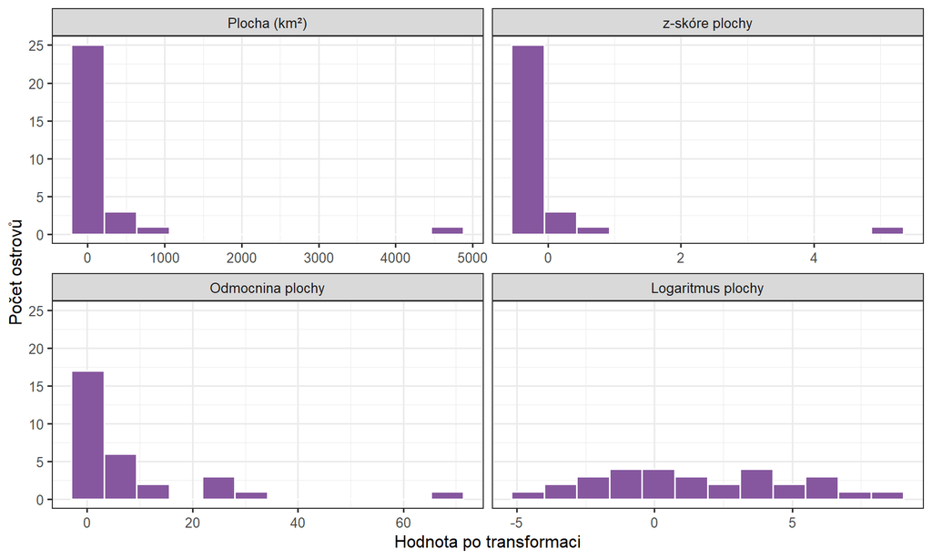

Plocha ostrovů v km², jako z-skóre, po odmocnění a po logaritmování.

Z-skóre zachovalo původní tvar. Logaritmus naopak malé hodnoty od sebe roztáhl a velké k sobě stlačil: rozdíl mezi 1 a 10 km² je na logaritmické škáleŠkála, na níž stejné vzdálenosti odpovídají stejným násobkům (např. 1, 10, 100); hodí se pro hodnoty rozprostřené přes několik řádů a pro násobné vztahy. stejně velký jako rozdíl mezi 1 000 a 10 000 km². **Odmocnina šikmostNesouměrnost rozdělení: u pravostranně šikmého rozdělení se hodnoty táhnou dlouhým chvostem vpravo k vysokým hodnotám a průměr bývá větší než medián. zmírnila, ale neodstranila. Logaritmus z extrémně šikmé plochy udělal přibližně souměrné rozdělení.** Malé ostrovy, které byly v původním histogramuGraf zobrazující rozdělení hodnot numerické proměnné: hodnoty jsou rozděleny do sousedních intervalů (košů), výška sloupce udává četnost v daném koši. namačkané v prvním koši, se rozprostřely přes celou osu.

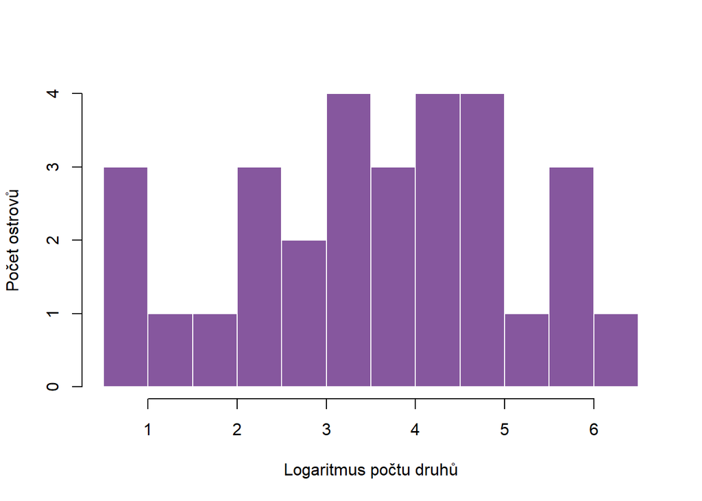

Histogram logaritmu počtu druhů.

```r
# Rozdělení logaritmu počtu druhů
hist(
  x = log(x = data_ostrovy$pocet_druhu),
  breaks = 10,
  col = "#86579E",
  border = "white",
  main = "",
  xlab = "Logaritmus počtu druhů",
  ylab = "Počet ostrovů"
)
```

Podobně se chová i počet druhů: po logaritmování již nemá dlouhý chvost vpravo. Veličinám, které jsou pravostranně šikmé, ale po logaritmování mají přibližně normální tvar, se říká **log-normální**. Typicky vznikají právě násobením mnoha náhodných vlivů, jako v simulaciOpakované vytváření umělých dat podle známého modelu na počítači; ukazuje, jak se odhady, intervaly nebo testy chovají napříč mnoha výběry. populací.

**PoznámkaKdy používáme logaritmus a kdy odmocninu?**

**Logaritmus** použijeme u kladných veličin, které se mění násobně nebo se liší o několik řádů:

- velikost populací, buněčné kultury a další procesy, které rostou nebo klesají o určité procento;
- koncentrace živin, toxinů nebo hormonů, které mezi vzorky kolísají o celé řády;
- velikost a hmotnost organismů napříč druhy, například hmotnost savců z první lekce;
- vztahy mezi rozměry těla (alometrie), například výška a průměr kmene stromu nebo počet druhů a plocha ostrova;
- situace, kdy nás zajímají relativní změny („o kolik procent“, „kolikrát“), nikoli absolutní rozdíly.

Logaritmickou škálu znáte i z běžného života: pH je záporný desítkový logaritmus koncentrace vodíkových iontů a decibely měří hlasitost na logaritmické škále.

**Odmocninu** použijeme u nezáporných veličin s mírnou pravostrannou šikmostí, zvláště u menších počtů, kde se objevují nuly (například počet semenáčků na ploše nebo počet hmyzu v pasti). Na rozdíl od logaritmu si s nulou poradí.

**Kdy ne:** pokud veličina obsahuje nuly nebo záporné hodnoty, logaritmus přímo použít nelze. U podílů mezi 0 a 1 a u počtů s mnoha nulami existují vhodnější modely, ke kterým se dostaneme později. A pokud jsou residuaRozdíl mezi pozorovanou hodnotou odezvy a hodnotou odhadnutou modelem: eᵢ = yᵢ − ŷᵢ. modelu v pořádku a biologické tvrzení je aditivní, transformace není potřeba.

**TipDoplňující: odlehlí savci z první lekce**

V první lekci krabicový graf tělesné hmotnosti 83 druhů savců označil 11 druhů jako možná odlehlá pozorováníPozorování, které se výrazně odlišuje od ostatních - v hodnotě jedné proměnné, nebo v modelu velkým residuem; může jít o chybu měření i o skutečně neobvyklý případ.. Hranice jsme tehdy počítali v kilogramech a logaritmickou osu jsme použili jen pro čitelnost. Co se stane, když hranice spočítáme až po logaritmování?

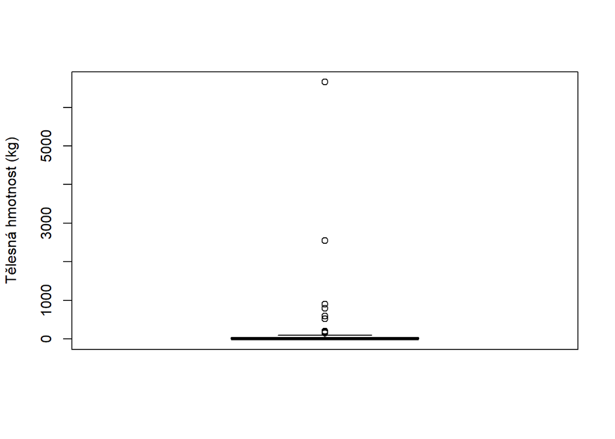

Tělesná hmotnost savců z první lekce v kilogramech.

```r
# Hmotnost savců z první lekce (balíček ggplot2)
vec_hmotnost <- ggplot2::msleep$bodywt

# Krabicový graf v kilogramech
boxplot(
  x = vec_hmotnost,
  ylab = "Tělesná hmotnost (kg)"
)
```

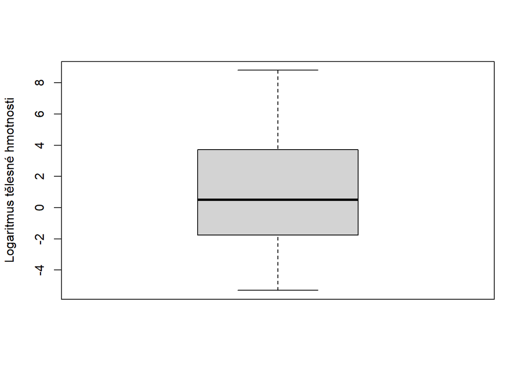

Stejní savci po logaritmování hmotnosti.

```r
# Krabicový graf logaritmu hmotnosti
boxplot(
  x = log(x = vec_hmotnost),
  ylab = "Logaritmus tělesné hmotnosti"
)
```

Po logaritmování neleží za vousy žádný druh. Savci označení v první lekci jako možná odlehlá pozorování tedy na logaritmické škále neobvyklí nejsou; leželi jen v dlouhém chvostu pravostranně šikmého rozdělení. Slon nebo velryba jsou skutečně velcí, ale na násobné škále, na které se velikost organismů mění, tolik nevybočují. **Označení odlehlé hodnoty proto závisí na tom, na jaké škále se díváme.**

## 5.8 Které transformace mění jen polohu a měřítko a které i tvar?

Přehled transformací z této části lekce.

| Transformace | Výpočet v R | Mění tvar? | Kdy se hodí |
| --- | --- | --- | --- |
| změna jednotek | `x * 100` | ne | převod mezi jednotkami |
| centrování | `x - mean(x)` | ne | intercept pro typickou hodnotu prediktoru |
| z-skóre | `(x - mean(x)) / sd(x)` nebo `scale(x)` | ne | porovnání veličin v různých jednotkách |
| odmocnina | `sqrt(x)` | ano, mírně zmenší pravostrannou šikmost | mírně šikmé nezáporné veličiny |
| přirozený logaritmus | `log(x)` | ano, výrazně zmenší pravostrannou šikmost | kladné veličiny, které se mění násobně |

Logaritmus má ještě jednu vlastnost, která je pro nás důležitější než souměrnost histogramuGraf zobrazující rozdělení hodnot numerické proměnné: hodnoty jsou rozděleny do sousedních intervalů (košů), výška sloupce udává četnost v daném koši.. Mění totiž nejen tvar rozděleníPopis toho, jaké hodnoty proměnná nabývá a jak často se vyskytují; může jít o pozorované rozdělení dat nebo o teoretické pravděpodobnostní rozdělení., ale i **tvar vztahu** mezi proměnnými. K tomu se dostaneme v další části.

# 6 Tvar vztahu

## 6.1 Jak vypadá vztah plochy a počtu druhů na logaritmických osách?

Vraťme se k ostrovům. Přímka selhala hlavně proto, že malé ostrovy byly namačkané u počátku a o sklonuParametr lineárního modelu udávající, o kolik se v průměru liší odezva dvou pozorování, jejichž prediktor se liší o jednu jednotku (při stejných hodnotách ostatních prediktorů). rozhodoval jediný obr. Co s tímto vztahem udělá logaritmus? Zobrazme stejné ostrovy dvakrát: na původních osách a na osách, kde jsou obě proměnné logaritmované.

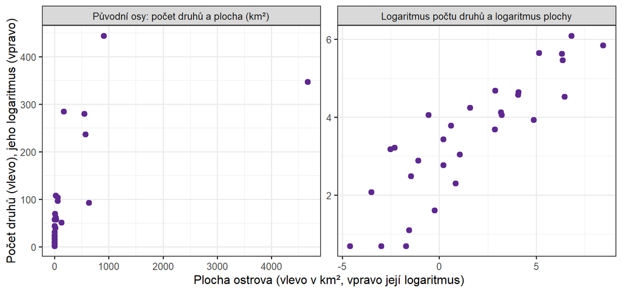

Vztah počtu druhů a plochy ostrova. Vlevo na původních osách, vpravo po logaritmování obou proměnných.

Stejný obrázek pravého panelu získáme i v základním R:

```r
# Bodový graf logaritmu počtu druhů podle logaritmu plochy
plot(
  x = log(x = data_ostrovy$plocha_km2),
  y = log(x = data_ostrovy$pocet_druhu),
  pch = 19,
  col = "#5D2890",
  xlab = "Logaritmus plochy",
  ylab = "Logaritmus počtu druhů"
)
```

**QuestionCo znamená přímka na logaritmických osách?**

Na logaritmických osáchŠkála, na níž stejné vzdálenosti odpovídají stejným násobkům (např. 1, 10, 100); hodí se pro hodnoty rozprostřené přes několik řádů a pro násobné vztahy. leží body přibližně podél přímky. Co to znamená pro vztah mezi plochou a počtem druhů? Nápověda: stejný krok na logaritmické ose odpovídá stejnému *násobku* původní hodnoty.

Vlevo je vztah zakřivený: u malých ostrovů počet druhů roste rychle, u velkých už pomaleji. Vpravo je přibližně přímkový. Na logaritmických osách znamená stejný krok doprava stejný násobek plochy a stejný krok nahoru stejný násobek počtu druhů. **Přímka na logaritmických osách tedy říká: když plochu vynásobíme určitým číslem, počet druhů se vynásobí jiným, stále stejným číslem.** Takovému vztahu se říká **mocninný vztah** (anglicky *power law*). V ekologii se pro ostrovy nazývá *vztah druhů a plochy* (*species–area relationship*).

**TipDoplňující: co na to Pearsonova a Spearmanova korelace?**

V lekci o korelaciBezrozměrné číslo popisující směr a těsnost vztahu dvou proměnných; Pearsonova korelace shrnuje lineární vztah a Spearmanova monotónní vztah podle pořadí. jsme u zakřiveného vztahuSituace, kdy vztah mezi prediktorem a odezvou není dobře popsatelný přímkou - má zakřivení nebo jinou nelineární formu. viděli, že Spearmanova korelace zůstala vysoká, zatímco Pearsonova byla nižší. Galapágy ukazují proč. Pearsonova korelace plochy a počtu druhů je na původních osách 0.62 a po logaritmování obou proměnných 0.87: měří těsnost kolem **přímky**, a přímka sedí lépe na logaritmických osách. Spearmanova korelace je v obou případech 0.88, protože pracuje s pořadím ostrovů a logaritmus pořadí nezmění. **Rozdíl mezi Pearsonovou a Spearmanovou korelací byl tedy upozorněním, že vztah je monotónní, ale není přímkový.** V lekci o korelaci jsme uvedli i druhou možnou příčinu takového rozdílu, vliv několika vzdálených bodů; na Galapágách působí obě, protože na původních osách přímku silně ovlivňuje Isabela.

## 6.2 Jaké tvary vztahu dávají biologický smysl?

Stejně jako v předchozí lekci sestavíme malou sadu kandidátních modelůJeden z malé sady modelů, které před analýzou formulujeme podle biologických hypotéz a pak porovnáme na stejných datech. a každý z nich zdůvodníme biologicky dříve, než uvidíme jakékoli srovnávací skóre.

Důležitá vlastnost lineárního modeluStatistický model, v němž je průměrná odezva součtem interceptu a prediktorů násobených koeficienty; lineární je v koeficientech, takže nemusí jít jen o přímku.: **„lineární“ znamená lineární v koeficientech, nikoli nutně přímka v grafu.** Model zůstává lineární, pokud je odezvaProměnná, jejíž variabilitu se snažíme vysvětlit nebo předpovědět; v notaci modelu y ~ x je odezva y. součtem koeficientů násobených nějakými hodnotami. Těmi hodnotami mohou být i `log(plocha_km2)` nebo druhá mocnina plochy. Funkce `lm()` proto umí popsat i zakřivený vztahSituace, kdy vztah mezi prediktorem a odezvou není dobře popsatelný přímkou - má zakřivení nebo jinou nelineární formu..

Pět kandidátních tvarů vztahu, definovaných před porovnáním.

| Kandidát | Biologické tvrzení | Formule v R |
| --- | --- | --- |
| A — přímka | Každý další km² přidá stejný počet druhů. | `pocet_druhu ~ plocha_km2` |
| B — logaritmus plochy | Každé zdvojnásobení plochy přidá stejný počet druhů. | `pocet_druhu ~ log(plocha_km2)` |
| C — mocninný vztah | Každé zdvojnásobení plochy vynásobí počet druhů stejným číslem. | `log(pocet_druhu) ~ log(plocha_km2)` |
| D — kvadratický člen | Počet druhů roste s plochou stále pomaleji, případně se pak obrátí. | `pocet_druhu ~ plocha_km2 + I(plocha_km2^2)` |
| E — logaritmus odezvy | Každý další km² zvýší počet druhů o stejné procento. | `log(pocet_druhu) ~ plocha_km2` |

Funkce `I()` v kandidátovi D říká R, aby výraz `plocha_km2^2` spočítal jako obyčejnou druhou mocninu. Bez ní by symbol `^` uvnitř formule měl jiný význam.

**QuestionKterý kandidát zní biologicky nejméně věrohodně?**

Pro každého kandidáta zkuste říct, zda jeho tvrzení zní rozumně pro ostrov o ploše 0,01 km² i pro ostrov o ploše 4 000 km². Který z nich vám připadá nejméně věrohodný?

Kandidát A předpokládá, že první km² malého ostrova přidá stejně druhů jako tisící km² velkého. Kandidát D umí vztah ohnout, ale kvadratická křivka je parabola: po vrcholu musí klesat, i když biologický důvod, proč by větší ostrov měl mít méně druhů, nemáme. Kandidáti B a C popisují zpomalující růst pomocí násobků plochy. Kandidát E předpokládá zrychlující exponenciální růst, který by u největších ostrovů predikoval obrovské počty druhů.

```r
# A: stejná přímka jako v části o předpokladech modelu
mod_a_primka <-
  lm(
    formula = pocet_druhu ~ plocha_km2,
    data = data_ostrovy
  )

# B: logaritmus plochy
mod_b_log_plochy <-
  lm(
    formula = pocet_druhu ~ log(plocha_km2),
    data = data_ostrovy
  )

# C: mocninný vztah, logaritmus obou proměnných
mod_c_mocninny <-
  lm(
    formula = log(pocet_druhu) ~ log(plocha_km2),
    data = data_ostrovy
  )

# D: přímka s kvadratickým členem
mod_d_kvadraticky <-
  lm(
    formula = pocet_druhu ~ plocha_km2 + I(plocha_km2^2),
    data = data_ostrovy
  )

# E: logaritmus odezvy
mod_e_log_odezvy <-
  lm(
    formula = log(pocet_druhu) ~ plocha_km2,
    data = data_ostrovy
  )
```

Počet druhů je počet, tedy celé nezáporné číslo. Pro taková data existují modely, které s počty pracují přímo; poznáme je v jedné z následujících lekcí. Pro otázku tvaru vztahu nám zde lineární modely s transformacemiMatematická operace použitá na hodnoty proměnné (např. logaritmus); mění tvar rozdělení i to, jaký vztah model popisuje, například násobný místo součtového. stačí.

## 6.3 Jak se kandidátní křivky shodují s ostrovy?

Modely C a E modelují logaritmus počtu druhů. Abychom všech pět kandidátůJeden z malé sady modelů, které před analýzou formulujeme podle biologických hypotéz a pak porovnáme na stejných datech. viděli na stejných osách, převedeme jejich odhady zpět na počet druhů funkcí `exp()`, která je opakem logaritmu.

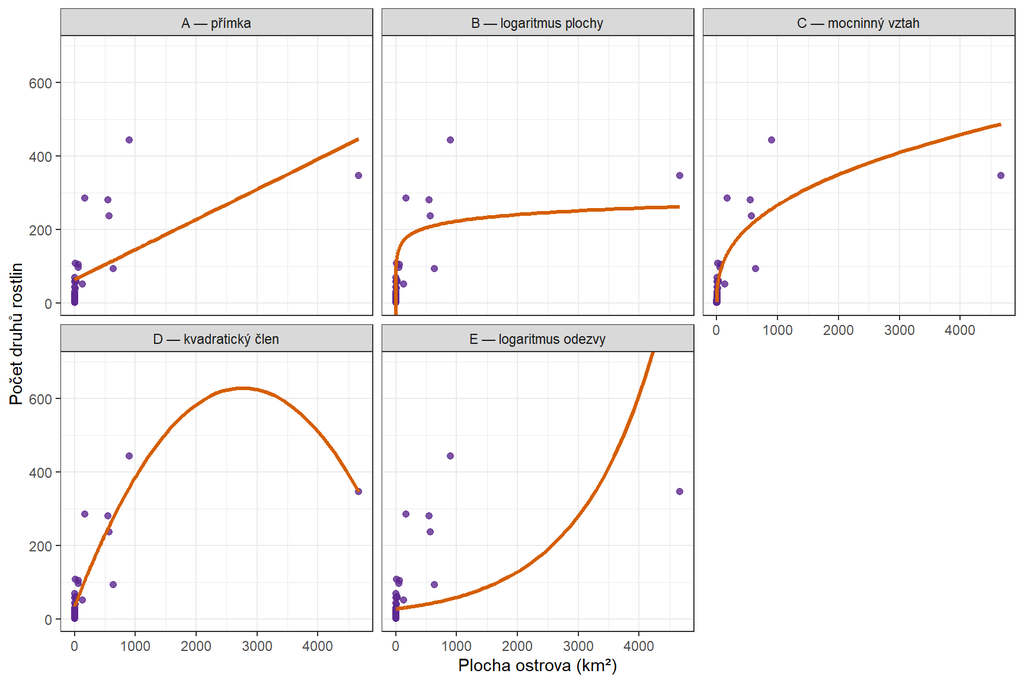

Pět kandidátních modelů převedených zpět na počet druhů. Body jsou stejné ostrovy ve všech panelech.

Přímka A stejně jako dříve vede nad většinou malých ostrovů. Křivky B a C rostou rychle u malých ostrovů a u velkých zpomalují. Parabola D prochází blízko velkých ostrovů, ale má vrchol kolem 2 766 km² a dál klesá. Pro větší plochy tedy predikuje *méně* druhů. Za vrcholem leží 1 ostrov (Isabela) a parabola se k němu ohýbá hlavně proto, že tento ostrov na ni má obrovský vliv (Cookova vzdálenostMíra vlivu jednoho pozorování na model: vyjadřuje, jak moc by se změnily odhadnuté hodnoty, kdybychom toto pozorování vynechali. 141.8). Exponenciála E zůstává téměř plochá a pak prudce stoupá, opačně než data.

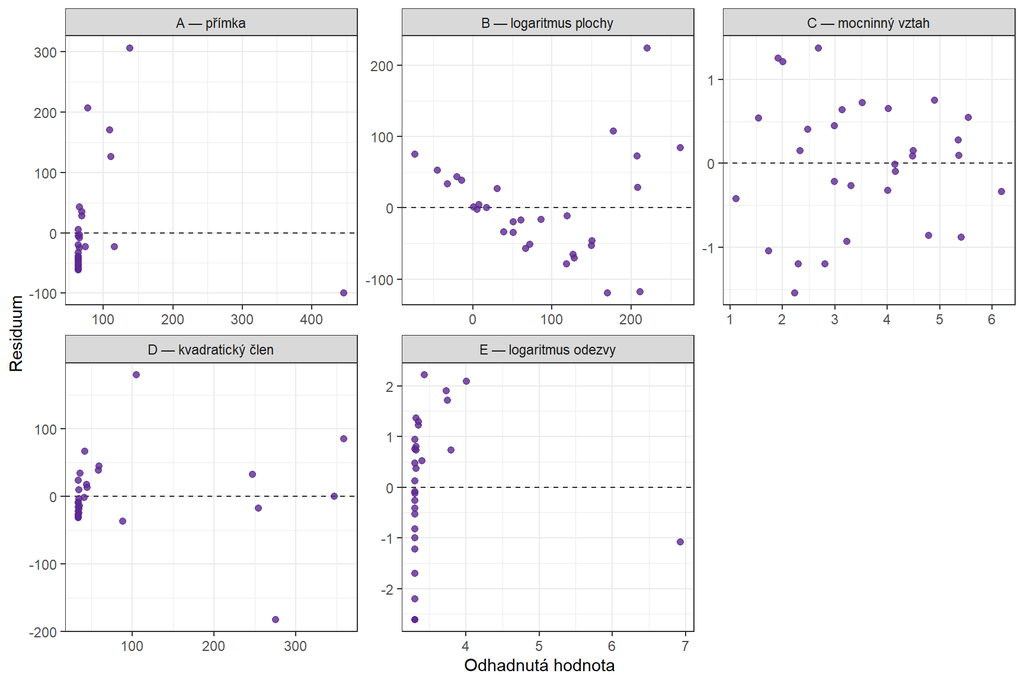

Residua pěti kandidátů podle jejich odhadnutých hodnot. U kandidátů C a E jsou residua i odhady na logaritmické škále, protože tyto modely modelují logaritmus počtu druhů.

Nejvyrovnanější pás residuíRozdíl mezi pozorovanou hodnotou odezvy a hodnotou odhadnutou modelem: eᵢ = yᵢ − ŷᵢ. kolem nuly má zatím kandidát C; podrobně jeho residua zkontrolujeme po srovnání AICMíra kvality modelu, která penalizuje složitost - čím nižší AIC, tím lepší poměr mezi přesností modelu a počtem jeho parametrů.. U ostatních zůstávají vějířeJev, kdy rozptyl residuí není konstantní podél hodnot prediktoru - typicky se rozptýlení residuí zvětšuje s rostoucí odhadnutou hodnotou. nebo oblouky.

**PoznámkaŠikmá odezva nemusí znamenat šikmá residua**

Model B používá jako odezvuProměnná, jejíž variabilitu se snažíme vysvětlit nebo předpovědět; v notaci modelu y ~ x je odezva y. přímo počet druhů, který je silně pravostranně šikmý (Shapiro–Wilkův test samotného počtu druhů: p < 0.001). U residuí modelu B test odchylku od normálního tvaru přesto neprokázal (p = 0.15). ŠikmostNesouměrnost rozdělení: u pravostranně šikmého rozdělení se hodnoty táhnou dlouhým chvostem vpravo k vysokým hodnotám a průměr bývá větší než medián. odezvy totiž z velké části vysvětluje šikmý prediktorProměnná, pomocí níž vysvětlujeme variabilitu odezvy; v notaci y ~ x je prediktor x.. **Proto kontrolujeme residua, nikoli samotnou odezvu.** Za lepší model to model B nedělá: jeho residua se směrem doprava rozšiřují.

Grafy residuí však samy neříkají, o kolik je jeden model lepší než druhý. K tomu jsme v předchozí lekci používali AIC.

## 6.4 Můžeme porovnat AIC modelu pro počet druhů a pro jeho logaritmus?

**QuestionKterý model má nejnižší AIC?**

Kandidát A má AICMíra kvality modelu, která penalizuje složitost - čím nižší AIC, tím lepší poměr mezi přesností modelu a počtem jeho parametrů. 360.2 a kandidát C má AIC 74.5. Znamená to, že je model C mnohem lepší?

Ne. Rozdíl 285.7 vypadá obrovsky, ale nic neříká. Pravidlo z předchozí lekce zní: **AIC lze porovnávat jen mezi modely se stejnou odezvouProměnná, jejíž variabilitu se snažíme vysvětlit nebo předpovědět; v notaci modelu y ~ x je odezva y. na stejných pozorováníchJeden zaznamenaný případ v datech, který obsahuje hodnoty jedné nebo více proměnných..** Model A popisuje počet druhů, model C jeho logaritmus. Logaritmus stlačí velké hodnoty, takže residuaRozdíl mezi pozorovanou hodnotou odezvy a hodnotou odhadnutou modelem: eᵢ = yᵢ − ŷᵢ. modelu C jsou čísla na úplně jiné škále než residua modelu A. AIC by se změnilo i tehdy, kdybychom použili logaritmus o jiném základu, aniž by se model jakkoli zlepšil. Stejné omezení platí pro R²Podíl variability odezvy zachycený modelem: R² = 1 − RSS / celkový součet čtverců (0 = model nezachytí nic navíc oproti průměru, 1 = zachytí vše).: u modelu A popisuje podíl variability počtu druhů, u modelu C podíl variability jeho logaritmu. Modely pro různé škály odezvy proto porovnáváme jinak: podle průběhu křivek převedených na původní osy a podle vzorů v residuích (nikoli podle velikosti residuí, která jsou v různých jednotkách).

Kandidáty proto porovnáme ve dvou oddělených skupinách:

AIC pěti kandidátů. Porovnávat lze jen řádky se stejnou odezvou.

| Kandidát | Odezva | AIC |
| --- | --- | --- |
| C — mocninný vztah | logaritmus počtu druhů | 74.5 |
| E — logaritmus odezvy | logaritmus počtu druhů | 110.8 |
| D — kvadratický člen | počet druhů | 334.5 |
| B — logaritmus plochy | počet druhů | 345.9 |
| A — přímka | počet druhů | 360.2 |

**Mezi modely pro počet druhů** (A, B, D) má nejnižší AIC kvadratický model D (334.5). Z předchozí kapitoly ale víme, že jeho tvar biologicky nedává smysl, jeho residua netvoří vyrovnaný pás a jeho průběh určuje jediný ostrov. **Nejnižší AIC neznamená, že model je biologicky obhajitelný.** AIC porovnává jen shodu a složitost v rámci zvolených kandidátů.

**Mezi modely pro logaritmus počtu druhů** (C, E) má mocninný vztah C mnohem nižší AIC (74.5) než model E (110.8).

Jako kontrolu, nikoli jako dalšího kandidáta, se můžeme ještě zeptat, zda mocninný vztah sám nepotřebuje zakřiveníSituace, kdy vztah mezi prediktorem a odezvou není dobře popsatelný přímkou - má zakřivení nebo jinou nelineární formu., tedy zda body na logaritmických osách neleží spíš podél oblouku než přímky. Přidáme-li k modelu C kvadratický členDruhá mocnina prediktoru přidaná do lineárního modelu (např. y ~ x + I(x^2)); umožní popsat oblouk, a model přitom zůstane lineární v koeficientech. `I(log(plocha_km2)^2)`, R² se změní jen z 0.757 na 0.758 a AIC vzroste na 76.3. Dodatečný koeficient si své místo nezaslouží.